# Cheng-ReputationBurningSponsorship-2025-MS.pdf

Converted from PDF `Cheng-ReputationBurningSponsorship-2025-MS.pdf` · 47 pages · anchors: page `#pN`, block `#pN-bK`

Page 1

1

#### **Reputation Burning: Analyzing the Impact of Brand Sponsorship on Social Influencers**

Mengjie (Magie) Cheng, macheng@hbs.edu, Harvard Business School

Shunyuan Zhang, szhang@hbs.edu, Harvard Business School

*ABSTRACT*

The growth of the influencer marketing industry warrants an empirical examination of the effect of posting

sponsored videos on influencers’ reputations. We collected a novel dataset of user-generated YouTube

videos created by prominent English-speaking influencers in the beauty and style category. We extracted a

rich set of theory-driven video features and used DiNardo-Fortin-Lemieux reweighting to construct

comparable treatment and control groups matched at the influencer-video level. The empirical analysis of

the matched sample revealed a *reputation-burning effect*; that is, posting a sponsored video, compared with

posting an equivalent organic video, cost the influencers 0.19% of their reputation (operationalized as the

number of subscribers). The reputation-burning effect was stronger among the influencers with larger

audiences. An analysis of likes, comments, and comment texts revealed a larger gap in audience response

between sponsored and organic videos among the influencers with larger (vs. smaller) audiences. The

reputation-burning effect was mitigated when a high fit existed between the sponsored content and the

influencer’s “usual” content and when the promoted brand was less well-known. Our study empirically

tested the assumption of several theoretical works. Moreover, it contributes to the literature on influencer

marketing and celebrity endorsements, and provides managerial implications for influencers, brands, and

social media platforms.

**Keywords:** influencer marketing; social influencer; brand sponsorship; video analytics

Electronic copy available at: https://ssrn.com/abstract=4071188

Page 2

2

*1. INTRODUCTION*

The influencer marketing industry was reportedly worth USD 6.0 billion in 2020, which is projected to

Market reports have shown that 75% of brands dedicated a specific budget to influencer marketing to

engage consumers and promote brands (Geyser 2021). For example, *The Ordinary* paid TikTok influencers

to post videos about the brand’s product Peeling Solution and generated more than $1 million in sales in

two weeks.<sup>1</sup>

Influencers are effective marketers because they engage large audiences on social media platforms

and appear as experts or trustworthy sources of information for their fans. They build reputations by creating

authentic, relevant, and interesting *organic* contents (Sokolova and Kefi 2019). Once influencers become

sufficiently popular, they can profit from their reputations by collaborating with brands to create *sponsored*

content (McQuarrie, Miller, and Phillips 2013). Our study focused on influencers’ reputations with their

audiences,<sup>2</sup> operationalized as numbers of subscribers. Avery and Israeli (2020) suggested that influencer

reputation is a key driver in influencer marketing because reputation is the foundation of an influencer’s

ability to obtain profitable offers from brands. Eldor (2019) referred to reputation as “the major currency in

the influencer and retail world.” However, while brands seek collaborations with influencers for their

reputations, several prior theoretical works have implicitly or explicitly assumed that sponsorships may

hurt the influencer’s reputation (Fainmesser and Galeotti 2021; Mitchell 2021), perhaps by causing the

audience to question the influencer’s authenticity (Forrester 2018). Empirically, the crucial question as to

whether and how sponsored content impacts influencer reputation remains unanswered.

Before we describe our research question and data, we first discuss the nature and implications of

influencer reputations and brand sponsorships. According to theoretical works in economics, reputation is

1 https://www.dailymail.co.uk/femail/article-8026573/Teenager-sparks-1-1MILLION-sales-Ordinary-skincareposting-TikTok.html. 2 Note that this measure might not be the same as the influencer’s reputation with the public. For example, Donald Trump may have a controversial reputation with the public but have a good reputation with his fans; our study focuses on the latter.

Electronic copy available at: https://ssrn.com/abstract=4071188

Page 3

3

an important asset that can be accumulated, consumed, and restored; that is, reputation can be cyclical (Liu

2011; Liu and Skrzypacz 2014). Liu (2011) characterized reputation dynamics as interactions between a

service provider (e.g., a firm or an influencer) and individual agents (e.g., consumers or an audience). The

agents observe the service provider’s behaviors and form or update beliefs about the provider's “type” (good

or bad reputation), which affects the agents’ willingness to have subsequent interactions with the service

provider. For example, if consumers observe that a firm handled a customer complaint poorly or launched

a bad product, then their perception of the firm’s reputation will be negatively affected, possibly stopping

them from purchasing from the firm if the perceived reputation is very poor.

Similarly, on social media, users observe an influencer’s posting behavior (e.g., the quality and

frequency of posts and whether posts are brand-sponsored) and form or update their perceptions of the

influencer’s reputation, which impacts whether users want to interact or continue to interact with the

influencer in the future. Users who perceive that an influencer has a good reputation may follow (or continue

to follow) in order to “listen to” the influencer, whereas users who perceive that an influencer has a bad

reputation may “reject” the influencer by unfollowing them or not following them in the first place.

Intuitively, a user’s decision to follow or unfollow an influencer reflects the user’s willingness to interact

with and hear from the influencer in the long run (Morton 2020). Thus, an influencer gains subscribers in a

cumulative process similar to reputation building over time (Mitchell 2021), and the influencer’s number

of subscribers reflects their reputation and ability to influence others. Brands look out for influencers with

many subscribers because subscriber counts indicate influencers’ power to influence and persuade people

(Eldor 2019), which is the brand’s motivation for collaborating with influencers (Avery and Israeli 2020).

How does brand sponsorship impact influencer reputation? Specifically, if an influencer’s content

characteristics remain similar, would their reputation benefit more from posting sponsored content than

from posting organic content? On the one hand, collaboration with brands may threaten the influencer’s

authenticity and affect the audience’s willingness to hear from the influencer (Audrezet, de Kerviler, and

Moulard 2020; Boerman, Willemsen, and van der Aa 2017). Many users are drawn to influencers who are

Electronic copy available at: https://ssrn.com/abstract=4071188

Page 4

4

“ordinary” people who seem intrinsically motivated (i.e., without commercial interests) to provide useful

information and thus are perceived as more authentic, relatable, and trustworthy than marketing

communications (van Driel and Dumitrica 2021; Haenlein et al. 2020). In a market survey, 62% of

consumers indicated that they were concerned that influencers capitalize on impressionable audiences and

that they might stop following an influencer who posted sponsored content (Forrester 2018). Previous works

on celebrity endorsement (Hung, Chan, and Tse 2011; Tripp, Jensen, and Carlson 1994) have found that

celebrities who endorse too many brands or products might lose credibility with their audiences. Thus,

compared with organic posting, brand sponsorship may hurt the influencer’s reputation, leading to a

*reputation-burning effect*.

On the other hand, several pieces of evidence support the prediction that, compared with posting

organic content, brand sponsorship might help an influencer’s reputation—a *reputation-strengthening effect*.

Sponsorship is evidence of the influencer’s worth and ability (Brooks 2020) and enables the audience to

access exclusive brand information (Casaló, Flavian, and Ibáñez-Sánchez 2018)*.* In our influencer video

posting dataset (collected from YouTube),<sup>3</sup> influencers received more likes and fewer dislikes on average

for sponsored content than for organic content. Furthermore, honesty is the best policy in word-of-mouth

marketing (Abendroth and Heyman 2013), and the audience may feel that an influencer is honest upon

seeing a brand sponsorship disclosure. The disclosure of sponsorship may help safeguard the audience’s

perception of authenticity, which is central to their relationship with the influencer (Evans, Wojdynski, and

Hoy 2018; Mediakix 2020b).

In summary, the effect of brand sponsorship on an influencer’s reputation remains ambiguous and

empirically untested. This research fills the gap by asking the following questions:

1) What is the impact (main effect) of posting sponsored content relative to posting similar organic

content on the influencer’s reputation (operationalized as the number of subscribers)?

3 https://youtube-dl.org/.

Electronic copy available at: https://ssrn.com/abstract=4071188

Page 5

5

Of course, users choose to subscribe and unsubscribe for diverse, multifactorial reasons.<sup>4</sup> We

focused on brand sponsorship as one possible reason and controlled for other observable reasons and tested

the sensitivity of our results to unobservable reasons (see Section 4.1.1).

We investigated three potential moderators: the influencer’s audience size, the “fit” between the

sponsored content and the influencer’s usual content, and brand popularity.

2) Does the impact of brand sponsorship vary with the influencer’s audience size? If so, what are the

possible reasons?

3) Does the impact of brand sponsorship vary with a) the *fit* between the influencer and the sponsored

content and b) the *popularity* of the brand?

We analyzed audience size because influencers with smaller audiences may generate more

engagement and trust, and their sponsored content tends to be perceived as more authentic and trustworthy

than the content of influencers with larger audiences (Barker 2019). Experticity (2016) found that 82% of

consumers considered a purchase recommendation trustworthy if it came from an influencer with a

relatively small audience.<sup>5</sup>

We analyzed “fit” because a high influencer–sponsorship *fit* is suggested to increase the

effectiveness of influencer marketing messages (Avery and Israeli 2020), while a lack of *fit* can decrease

the believability of the message and hurt the credibility and trustworthiness of the influencer. Similarly, the

match-up hypothesis in the celebrity endorsement literature (Kirmani and Shiv 1998; Knoll and Matthes

2017) predicts that a better celebrity–brand *fit* leads to more-positive brand evaluations and more-effective

celebrity endorsements.

4 For example, subscribers may choose to stop following an influencer because of rumored or confirmed inappropriate behavior such as the old racist tweets of Elle Darby on YouTube. A viewer may follow or unfollow an influencer because of a friend’s recommendation. A viewer may follow an influencer but then not watch any subsequent videos simply because the viewer stops spending time on YouTube. Such instances are unlikely to correlate with brand sponsorship and thus should not alter our main results. 5 A “relatively small audience” is defined as 1,000 to 100,000 subscribers; these influencers may also be described as “micro-influencers,” in contrast to “macro-influencers” (https://www.socialmediaexaminer.com/how-to-partner-withyoutube-micro-influencers/, accessed on January 11, 2022).

Electronic copy available at: https://ssrn.com/abstract=4071188

Page 6

6

Finally, we analyzed brand popularity because once an associative link is formed between an

influencer and the brand, the audience’s perceptions of the brand may spill over onto the influencer and

vice versa (Batra and Homer 2004; McCracken 1989), just as endorsements from beloved celebrities can

improve brand perceptions (Arsena, Silvera, and Pandelaere 2014; Miller and Allen 2012). In addition, the

viewer’s utility from viewing sponsored content may depend on the brand’s popularity (Rochet and Tirole

2006), which may influence their willingness to (continue to) interact with the influencer who features a

particular brand in creating the content.

This study analyzed a unique dataset of 85,669 user-generated YouTube videos created by 861

active English-speaking influencers in the beauty and lifestyle category. For each influencer, we collected

the daily number of subscribers (as a proxy for the influencer’s dynamic reputation) and daily content-

posting behavior from August 2019 to July 2020. For each video, we collected the audience engagement

information (the number of views, likes, dislikes, and comments), whether the video was sponsored or

organic, and the video features according to four categories: basic video properties (Zhou et al. 2021), the

influencer’s emotions and appearance (Zhang et al. 2021), the influencer’s voice (Hwang, Liu, and

Srinivasan 2021), and visual aesthetics (Yeh et al. 2013). We included these categories because they can

affect the viewer’s attention, engagement, and perceived interpersonal relationship with the influencer

(Ekman and Oster 1979; Zhang et al. 2022).

The treatment effect indicates the reputation impact of a YouTube influencer posting a *sponsored*

video (the treatment group) compared with a counterfactual, when a similar influencer posts a similar

*organic* video (the control group). To replicate such comparisons, we constructed comparable treatment

and control groups by matching our samples at the influencer-video level. We employed the DiNardo-

Fortin-Lemieux (DFL) reweighting method for the matching step (DiNardo, Fortin, and Lemieux 1996;

details are in Section 3.2). On the basis of this matched sample, we report three main findings.

*First*, the empirical analysis of the matched sample revealed a *reputation-burning* effect: posting a

sponsored video relative to posting an organic video with similar characteristics cost the influencers 0.19%

Electronic copy available at: https://ssrn.com/abstract=4071188

Page 7

7

of their subscribers on average. A back-of-the-envelope calculation suggests that the effect due to a single

sponsored video translates to an average loss of roughly 79,800 views for an influencer in a year (the

calculation details can be found in Section 4.1). *Second*, the *reputation-burning* effect was stronger among

the influencers with larger audiences. To understand why, we analyzed three audience response variables:

the number of likes, number of comments, and amount of trust reflected in the comment text. For all three

variables, we found a larger gap between the sponsored and organic videos among the influencers with

larger (vs. smaller) audiences. *Third*, an interesting heterogeneity was observed in the sponsorship effects.

A high fit between the sponsored content and the influencer’s “usual” content is likely to mitigate the

reputation-burning effect, perhaps because a high fit makes the influencer look like a more credible source

of product information (Sternthal, Dholakia, and Leavitt 1978). The reputation-burning effect was mitigated

when the brand involved in the video was less well-known, perhaps because the influencer can provide

brand information to which the audience would otherwise not have easy access (Casaló, Flavian, and

Ibáñez-Sánchez 2018). Our main results were robust to an extensive set of robustness tests, including

hypothetical unobserved confounders, alternative model specifications, and alternative mechanisms.

Details are in Web Appendix Sections B, D, and E.

Our research effort contributes to the emerging literature on influencer marketing (e.g., Huang and

Morozov 2022; Pei and Mayzlin 2021) by empirically testing a fundamental assumption of several

theoretical works: that brand sponsorship causes reputation harm to social influencers (Fainmesser and

Galeotti 2021; Mitchell 2021). For example, Mitchell (2021) modeled the dynamic relationship between an

influencer and a subscriber. The relationship involves a “reap and sow” cycle in which the influencer

oscillates between giving unbiased advice and monetizing the opportunity to advise. The derived cycle is

built on the *assumption* that pursuing the most revenue (through sponsored content) will hurt the

influencer’s reputation, but we are among the first to *empirically* show the reputation-burning effect.

We also enrich the influencer marketing literature by focusing on how influencers’ decisions to post

sponsored content affect the outcomes for the influencers themselves. By contrast, prior research on the

Electronic copy available at: https://ssrn.com/abstract=4071188

Page 8

8

outcomes of influencer marketing has focused on the consumer and the firm rather than the influencers.

Specifically, researchers have studied predictors of the number of likes and comments on sponsored

contents (Ershov and Mitchell 2020; Hughes, Swaminathan, and Brooks 2019; Wies, Bleier, and Edeling

2022), the likelihood of reposting a sponsored content (Leung et al. 2022; Valsesia, Proserpio, and Nunes

2020), product sales (Bharadwaj et al. 2022), and purchase intentions (Lee and Eastin 2020). Leung et al.

(2022) found that sponsored content was reposted more times when the influencer had more subscribers,

when the post included the brand name in a hashtag, and when more of the influencer’s subscribers had

interests in the domain of the sponsored brand (such that the brand “fits” the subscribers). Ershov and

Mitchell (2020) found that adopting advertising disclosure regulations leads to fewer likes and comments

on influencers’ content and lower consumer welfare, perhaps because followers in social media do not like

sponsored content. In addition, our findings show the importance of studying outcomes for influencers as

a complement to outcomes for firms. For example, although influencers with larger audiences are attractive

candidates for brand sponsorship because they can reach many customers (e.g., number of reposts; see

Leung et al. 2022), we found that for influencers with larger audiences, brand sponsorship has a more

pronounced negative impact and elicits more adverse reactions from the audience. This is perhaps because

influencers with smaller audiences often form stronger ties and build more trust with their audiences (Wies,

Bleier, and Edeling 2022).

Our focus on influencer reputation contributes to the nascent literature on influencer video

advertising. Rajaram and Manchanda (2020) implemented an interpretable deep learning architecture to

analyze the relationship between influencer video content and video engagement. Yang, Zhang, and Zhang

(2021) developed an algorithm to predict the sales lift from sponsored videos. We complemented these

works by analyzing the video content itself to construct comparable sponsored and organic influencer-video

pairs with which we can examine consequences for influencers rather than for consumers or firms.

Finally, our heterogeneity analyses complemented the existing research on how audiences react to

influencer marketing, and the results provide interesting comparisons with the existing literature on

Electronic copy available at: https://ssrn.com/abstract=4071188

Page 9

9

celebrity endorsements (e.g., Amos, Holmes, and Strutton 2008). Consistent with the source credibility

model and product matchup hypothesis in the celebrity endorsement literature (Choi and Rifon 2012;

Sternthal, Dholakia, and Leavitt 1978), we found that influencer-video fit mitigates the reputation-burning

effect. We speculated that sponsored videos may seem more authentic and trustworthy when on topics for

which the influencer has built credibility and expertise. In contrast to the value transfer model (McCracken

1989), which implies that more popular products may spill over onto the influencer, we found that

influencers fare better when they promote less-well-known brands.

Our findings have crucial managerial implications for influencers, brands, and social media

platforms. For *influencers*, our estimation of the effect of posting a sponsored video offers a baseline with

which influencers can evaluate the hidden economic trade-off involved in sponsorship offers. Our findings

also suggest that influencers could be strategic in the timing and content of sponsored videos. It is advisable

that influencers post sponsored content when the content is aligned with their usual style and when the

sponsoring brands are less well-known. For *brands*, we offer insights into influencer selection; most brands

currently use the number of subscribers as a primary criterion to choose influencers (Hwang, Liu, and

Srinivasan 2021). However, our results suggest that influencers with more subscribers may not necessarily

be the best brand partners. In fact, when promoting a brand, influencers with larger audiences tend to elicit

more negative audience reactions, including fewer comments, lower engagement, and reduced trust, than

influencers with smaller audiences. Such negative audience reactions may also extend to the promoted

brand. Lastly, social media *platforms* should be advised that brand sponsorship will hurt influencer

reputation and receptivity among audiences, potentially “turning audience away.” Platforms could caution

influencers about the risks of sponsorship and motivate them to post organic content, thereby reducing the

exodus of active users who have lost trust in influencers and become less engaged on the platform.

Electronic copy available at: https://ssrn.com/abstract=4071188

Page 10

10

*2. RESEARCH CONTEXT AND DATA*

Our research context was YouTube, a major global influencer marketing platform. As of 2020, YouTube

has an estimated 2.1 billion users. We focused on the beauty and lifestyle category because it attracts the

highest volume of brand sponsorships (Schwemmer and Ziewiecki 2018).

YouTube influencers are often categorized by the number of subscribers: nano (1000 or less), micro

(1,000–100,000), macro (100,000–1 million), and mega-influencers (more than 1 million) (Sonnenberg

2021). This breakdown reflects the assumption employed by many marketers that influencers’ subscriber

counts positively predict their marketing impacts. Our data include micro-, macro-, and mega-influencers.

We do not include nano-influencers because they tend to post infrequently and are less likely to receive

sponsorship offers (Weber 2018). We needed a sample of influencers who post sponsored content and post

frequently enough that we can exploit variations in the postings. Following Hwang, Liu, and Srinivasan

(2021), we collected data on 861 active influencers<sup>6</sup> in the beauty and style category on YouTube. We

downloaded 85,669 videos (approximately 2.5 terabytes and 900,000 minutes) posted by the influencers

between August 2019 and July 2020.

*2.1. Influencer and Sponsorship Data*

We obtained each influencer’s number of subscribers and video views each day during the observation

window from a data tracking website, noxinfluencer.com.<sup>7</sup> In the main analysis, we used the number of

subscribers as the proxy for the influencer’s reputation among their fans because gaining subscribers is a

cumulative process similar to building reputation over time (Mitchell 2021). Intuitively, a user’s decision

6 We first retrieved the list of the top 1,000 most active influencers in the beauty and style category at https://channelcrawler.com/eng/results/1917 in August 2020 (the data displayed at the time of reading may differ from our dataset). We removed (a) invalid/unavailable YouTube channels, (b) videos that could not be found at the time of data retrieval, (c) videos with downloading errors, and (d) videos that resulted in feature extraction errors due to file corruption. We ended up with 861 influencers and 85,669 posted videos. 7 An influencer’s number of subscribers can change in two ways: new subscribers may follow the influencer, and old subscribers may unfollow the influencer. Both happen to every influencer, but we do not have data to differentiate between the two processes; instead, we observed the aggregate change in the number of subscribers over time. Our analyses uncovered the *relative* aggregate change between posting a sponsored video and posting a similar organic video.

Electronic copy available at: https://ssrn.com/abstract=4071188

Page 11

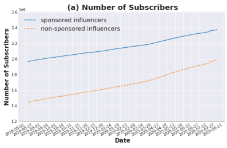

NOTE: figure/graphic rendered as an image from the PDF; its content is not machine-readable text. Caption (if any) follows as the next block.

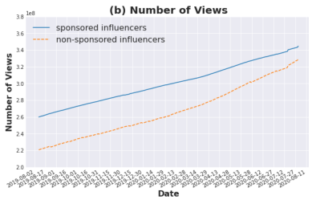

NOTE: figure/graphic rendered as an image from the PDF; its content is not machine-readable text. Caption (if any) follows as the next block.

11

to follow or unfollow an influencer reflects the user’s perception of their relationship with the influencer.

We also collected key influencer characteristics, including their age, gender, and the length of channel title

(measured by the character count). In addition, we documented the influencers’ posting behaviors,

including the number of days since their last video posting, the number of days since their first video posting,

and their average video upload frequency.

In our study, we defined “a sponsored video” as a YouTube video created by an influencer in

collaboration with a brand. We did not distinguish between the specific format of this sponsorship or how

the brand was presented. Instead, following Hwang, Liu, and Srinivasan (2021), we identified sponsored

videos on the basis of the influencer’s sponsorship disclosure in the video description box (e.g., “This video

is in collaboration with XX brand”). This approach aligns with the guidelines of the Federal Trade

Commission on celebrity endorsements (FTC 2019), which mandate influencers to transparently disclose

their brand collaborations. We found that 5,993 (7.0%) of the 85,669 videos were sponsored and that 333

(38.7%) of the 861 influencers posted at least one sponsored video during our observation window. We

refer to the 333 influencers as “sponsored influencers” and the remaining 528 as “non-sponsored

influencers.”

**Figure 1. Reputations of Sponsored and Non-sponsored Influencers Over One Year**

Note: “Sponsored influencers” are those who posted at least one sponsored video during our observation window, and “non-sponsored influencers” are those who never posted sponsored videos during our observation window.

Figure 1 illustrates the evolution of (a) the average subscriber count and (b) the average view count

of the sponsored and non-sponsored influencers. Although the sponsored influencers had more views and

Electronic copy available at: https://ssrn.com/abstract=4071188

Page 12

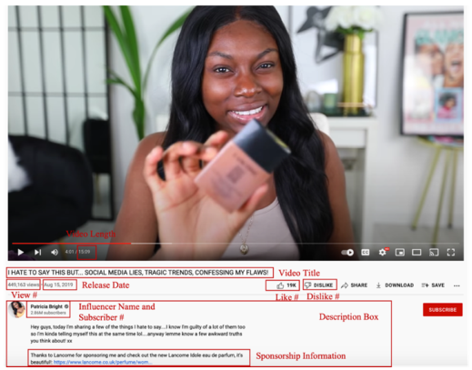

NOTE: figure/graphic rendered as an image from the PDF; its content is not machine-readable text. Caption (if any) follows as the next block.

12

subscribers than the non-sponsored influencers, the two groups converged slightly on both metrics during

the observation window, consistent with the prediction that posting sponsored content may harm the

influencer’s reputation relative to posting organic content.

*2.2 Video Data*

For each YouTube video in the sample, we collected audience engagement information (the number of

views, likes, dislikes, and comments) and video release information (date, video length, title, and

description) from the video’s YouTube page (see an example in Figure 2).

**Figure 2. Information Collected from Each YouTube Video<sup>8</sup>**

Note: This is a screenshot of a YouTube video posted by influencer Patricia Bright. The red boxes highlight the audience engagement information (the number of views, likes, dislikes, and comments) and release information (date, video length, title, and description). We extracted sponsorship disclosure information from the video description box. We used machine learning models to extract the images, audio, and speech from each video. To

capture what the audience can see, hear, and feel about the influencer, we then theorized and extracted 33

variables in four categories that may affect the viewer’s attention and engagement: basic video properties

and the influencer’s emotions and appearance, voice, and visual aesthetics. Table 1 delineates the video

features into four categories. The technical details are in Web Appendix Section A.1.

8 https://www.youtube.com/watch?v=deudMVwDqqk, accessed on January 10, 2022.

Electronic copy available at: https://ssrn.com/abstract=4071188

Page 13

13

*Basic Video Properties.* We considered five variables (video length, scene number, average scene

length, speaking rate, and sentiment) that may affect attention and engagement (Zhou et al. 2021).

*Influencer's Emotions and Appearance.* We first identified any human faces in the video, as the

human face is a primary channel for nonverbal communication (Ekman and Oster 1979). For each video

values across the images for each emotion. We extracted five appearance features (gender, age, smile,

attractiveness, and number of faces) that may affect the perceptions of the influencer’s personality, which

could affect their reputation (Zhang et al. 2021).

*Influencer’s Voice Features.* An influencer may adjust their voice in sponsored videos (Hwang,

Liu, and Srinivasan 2021). We used techniques from affective computing (Scherer, London, and Wolf 1973)

and automated speech recognition (Eyben, Wöllmer, and Schuller 2010) to extract four vocal features

(loudness, pitch, loudness variability, and talking duration) that may affect the viewer’s perception of traits

such as dominance (Scherer, London, and Wolf 1973), attractiveness (Fraccaro et al. 2011), and capability

(Peterson, Cannito, and Brown 1995).

*Visual Aesthetics.* We measured two types of aesthetic features because aesthetics can affect viewer

preferences and satisfaction (e.g., Moorthy, Obrador, and Oliver 2010; Yeh et al. 2013). Following Zhang

et al. (2022) and Zhou et al. (2021), we extracted three motion features (foreground motion area, motion

magnitude, and motion direction) and five color features (warm hue proportion, saturation, brightness,

contrast of brightness, and clarity).

**Table 1. Definitions of the Video Features**

| VideoLength SceneNumber | BasicVideoProperties Lengthinseconds . Numberofscenes . |
| --- | --- |
| AverageSceneLength | Average amount of time between scene cuts (in seconds) computed based , onintelligentscenecutdetection . |
| SpeakingRate Sentiment | Numberofspokenwordspersecond . Averagesentiment basedonthesubtitletext , . |
|  | TheInfluencer’sEmotionsandAppearance |

NOTE: table converted from PDF layout to HTML text; cell boundaries are reconstructed. See PDF if exact alignment matters.

9 https://www.faceplusplus.com/emotion-recognition.

Electronic copy available at: https://ssrn.com/abstract=4071188

Page 14

14

Emotion

We focus on five emotions: anger, happiness, neutrality, sadness, and

surprise. For each emotion, we calculate a number in the range [0,100], with larger values indicating higher confidence in the state. Gender Gender analysis result; we transform it to binary (1 = female). Age Age analysis result; a non-negative integer. Smile A number in the range [0,100]; larger values indicating more smiling.

Facial Attractiveness Separate values for female and male; a number in the range [0,100], with

larger values indicating that the face is more attractive. Face Sum Number of faces detected in one scene. *The Influencer*’*s Voice Features (Mean + Standard Deviation)* Loudness Vocal intensity as a narrow-band approximation from the voice signal. Pitch F0 (in Hz): the fundamental frequency.

Loudness Variation Zero-crossing rate: the number of times in a given interval that the amplitude

of the speech signal passes through zero.

Talking Duration

The fraction of time in a given interval that a person is speaking. Calculated

as the inverse of the maximum frequency using the autocorrelation function (ACF).

*Visual Aesthetics* *Motion Features* Foreground Motion Area

Average percentage of the foreground in which motion occurs, computed

based on background/foreground segmentation.

Motion Magnitude Average motion magnitude measured in pixels, computed based on dense

optical flow.

Motion Direction Average motion direction measured in degrees, computed based on dense

optical flow. *Color Features* Warm Hue Proportion Average proportion of pixels with warm colors (e.g., yellow, red) in a frame. Saturation Average saturation of all pixels in a frame. Brightness Average intensity of all pixels in a frame. Contrast of Brightness Standard deviation of the pixel intensity across the whole frame. Clarity The proportion of pixels with sufficient brightness (> 0.7) in a frame. Note: For the measures that we estimated at the scene-level (the influencer’s emotions and appearance features, and some basic video properties), we took the mean value of all scenes in the video to create video-level measures. As a robustness check, we used the emotion features calculated only in the first scene, and we obtained consistent findings.

*3. EMPIRICAL FRAMEWORK*

*3.1. Treatment and Control Groups*

The treatment, *brand sponsorship*, occurs whenever an influencer posts a sponsored video. We

measured the impact of *brand sponsorship* on the influencer’s reputation three days after the posting.<sup>10</sup> To

10 We focused on the reputation three days after video posting for two reasons. First, most video views occur shortly after posting (a plot of the cumulative video views against the number of days since posting revealed a concave growth

Electronic copy available at: https://ssrn.com/abstract=4071188

Page 15

15

estimate the impact of brand sponsorship on the influencer’s reputation, we needed to minimize the

influence of other factors that systematically varied according to sponsorship status and that might affect

reputation. Ideally, we hoped to find “twin influencers” (pairs with identical characteristics such as gender,

reputation, and career stage) and randomly assign them “twin videos” (pairs identical in content, length,

quality, etc., except for the sponsorship condition). However, this design is managerially infeasible. In

Section 3.2, we describe how we constructed a matched sample to mimic or approximate such a design.

Our research context posed three challenges to the valid identification of the treatment effect from

the observational data. First, brand sponsorship (i.e., the treatment) was irregular and sequential for each

influencer: the influencers did not follow any particular timeline or pattern of video posting. Hence, we

could not simply use one period or a uniform set of periods to split the data into pre-treatment and post-

treatment periods. Second, the treatment effect might carry over to later periods such that a sponsored video

might affect not only the influencer’s immediate reputation but also the audience’s reaction to subsequent

videos. Third, the observational nature of the data comes with possible endogeneity from the influencer–

brand selection process, leading to systematic differences between treatment and control groups. For

example, brands may only work with certain types of influencers, and sponsored content may also be

significantly different from organic content.

Inspired by Azoulay, Zivin, and Wang (2010), we addressed the first two challenges with our

construction of the treatment and control groups of influencer-video pairs and addressed the third challenge

with DFL reweighting in Section 3.2. By analyzing each influencer-video pair as a separate event, we

eliminated consideration of within-influencer variation in posting patterns, thereby avoiding the issue of

irregular, sequential video posting. An influencer-video pair belongs to the treatment group if the video is

sponsored, and it belongs to the control group if the influencer did not post any sponsored videos during

the observation window (i.e., non-sponsored influencers, as defined in Section 2.1). By excluding organic

curve). Second, three days is a short enough posttreatment window to minimize the risk of overlap between consecutive video postings (median number of videos posted per week in our dataset: 1.39). As a robustness check, we used the reputation two, four, and five days after video posting and obtained similar results.

Electronic copy available at: https://ssrn.com/abstract=4071188

Page 16

16

videos posted by sponsored influencers, we avoided the possibility of a carryover effect from a sponsored

video to subsequent organic videos. The final sample contained 63,880 videos, with 57,991 organic videos

in the control group and 5,889 sponsored videos in the treatment group.<sup>11</sup>

We followed the matched sampling approach employed in previous works that had similar research

settings and identification challenges as our study (Azoulay, Zivin, and Wang 2010; Jäger 2016). For

example, Azoulay, Zivin, and Wang (2010) estimated how the unexpected deaths of 112 academic

“superstars” impacted their collaborators’ publication rates. The authors constructed a matched control for

each scientist who experienced the death of a superstar collaborator (i.e., superstar–collaborator pairs) and

estimated the matched sample. Although our study is similar in many ways, the nature of an influencer’s

sponsorship decision was endogenous (as is the joint decision of the brand and influencer), while the

premature deaths of collaborators were exogenous in Azoulay, Zivin, and Wang (2010). Given the treatment

endogeneity in our setting, we matched organic influencer-video pairs and sponsored influencer-video pairs

on a set of observed influencer and video characteristics that might influence the brand sponsorship decision.

Furthermore, we employed the Rosenbaum bounds test to verify that our results are robust to the

hypothetical unobservables that might affect the brand sponsorship process and influencer reputation

simultaneously.

Table 2 presents the summary statistics for the treatment and control groups The groups were not

balanced, as indicated by significant differences between the two groups. For example, the videos in the

treatment group were longer (diff. = 290.8, p £ 0.001) and contained more words (diff. = 116.4, p £ 0.001).

Such differences may influence both the likelihood and outcome of the treatment, thereby threatening the

identification strategy (Athey and Imbens 2006). Next, we dealt with this issue by matching influencer-

video pairs on their observed characteristics.

11 The final number of video samples (63,880) is different from the number of raw video samples (85,669) because we excluded organic videos from sponsored influencers (i.e., those who posted one or more sponsored videos during the sample period). Audience reactions to these organic videos might have been influenced by preceding sponsored videos, and contamination might bias our estimates, similar to the challenges faced in Azoulay, Zivin, and Wang (2010) and Jäger (2016). In addition, we excluded the 104 sponsored influencer-video pairs that did not match.

Electronic copy available at: https://ssrn.com/abstract=4071188

Page 17

17

**Table 2. Summary Statistics of the Key Variables**

[output not shown]

NOTE: table converted from PDF layout to HTML text; cell boundaries are reconstructed. See PDF if exact alignment matters.

Electronic copy available at: https://ssrn.com/abstract=4071188

Page 18

18

[output not shown]

NOTE: table converted from PDF layout to HTML text; cell boundaries are reconstructed. See PDF if exact alignment matters.

Most sponsored posts are made through a two-step process: (1) the brand reaches out to the influencer with

whom it hopes to partner, and (2) the influencer decides whether to collaborate with the brand. Brands

choose influencers on the basis of several selection criteria such as reach/reputation (typically measured as

the number of subscribers), engagement rate, relevance, content quality, and frequency of posts (Avery and

Israeli 2020; Hwang, Liu, and Srinivasan 2021). For instance, the beauty tool and skincare product brand

Vanity Planet considers both the influencer’s subscriber count and average view count.<sup>12</sup> Influencers do not

always accept sponsorship offers; they may decline because they want to take a break from making videos

or are dissatisfied with a brand’s financial offer (Hwang, Liu, and Srinivasan 2021; Mediakix 2020a). Thus,

we should include influencer characteristics to account for the likelihood that an influencer will receive a

sponsorship offer (e.g., days since the first video posting, the frequency of video postings, and pre-posting

reputation) and the likelihood that the influencer will accept a sponsorship offer (e.g., whether the video is

posted on a weekend, which might affect the influencer’s availability).

12 Vanity Planet influencer application website: https://www.vanityplanet.com/pages/influencer-application.

Electronic copy available at: https://ssrn.com/abstract=4071188

Page 19

19

Although we do not have data on factors such as the brand’s marketing budget and the influencer’s

compensation, the audience also does not know such information. Thus, such factors cannot directly

influence how the audience reacts to a sponsored video, although they may affect the audience’s reaction

*indirectly* through the content quality. For example, generous compensation may lead to a higher-quality

video or a happier influencer in the video. We can capture these possible indirect effects by controlling for

video features.

We used DFL reweighting (DiNardo, Fortin, and Lemieux 1996), a semiparametric weighting

approach that balances a sample on observed characteristics. The DFL reweighting method constructs

comparable treatment and control groups by first computing a sample weight for each given unit based on

the propensity score (Rosenbaum 2002; Rosenbaum and Rubin 1985) and then assigning weights to each

unit to eliminate any existing systematic differences between the treated and untreated units in terms of the

observed covariates that explain the treatment probability. For example, if the control influencer-video pairs

have a higher proportion of high-quality videos than the treatment influencer-video pairs, then the DFL

procedure will downweight high-quality videos and upweight low-quality videos in the control group. That

is, the DFL method creates a “synthetic” sample of weighted treatment and control groups in which the

observed covariates are balanced across the two weighted groups (Zhang et al. 2021). The DFL reweighting

method is widely applied in various contexts such as innovation (Bell et al. 2019), corporate finance (Yagan

2015), and labor economics (LaLumia 2013).

The DFL method serves a similar purpose as matching methods such as propensity score matching

(PSM; see Rosenbaum and Rubin 1985). One significant advantage of the DFL method is that unlike

matching methods, in which units in two groups that are not very similar to each other are discarded, the

DFL method does not discard any unit when creating a balanced sample and thus better preserves the sample.

This is because the “less similar” units are taken care of by the sample weight. Previous studies have also

shown that reweighting methods such as DFL reweighting are more efficient estimates with lower mean

Electronic copy available at: https://ssrn.com/abstract=4071188

Page 20

20

squared errors than those from matching methods (see Hirano et al. 2003, Firpo 2007, Austin and Stuart

2015).

We employed the DFL method to match the sample at the influencer-video pair level and ensured

that the weighted treatment and control groups were comparable on an extensive set of influencer and video

characteristics. For the influencer characteristics, we included the frequency of weekly video postings, days

since the last video posting, length of the channel title, number of days since the first video posting, age,

gender, and the influencer’s reputation three days prior to video posting. We included the video features as

described in Table 1.

The DFL method was implemented as follows. For each influencer (*i*)-video (*j*) pair *ij*, we

calculated the sample weight using the estimated propensity score, 𝑝𝑠!" (Rosenbaum and Rubin 1985),

which is computed as a logistic function of the influencer and video features 𝑋!" mentioned previously. We

denoted the fraction of the sample in the treatment group as 𝑠𝑝𝑜𝑛𝑠𝑜𝑟 '''''''''''. The sample weight with DFL

reweighting for each unit *i* is given in the following equation:

**equation / math rendering (image)**

NOTE: contains mathematical notation; text above is the PDF text layer and symbols may be mis-extracted. Image shows the original.

1 if influencer 𝑖 is in the treatment group

**equation / math rendering (image)**

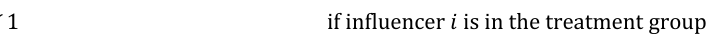

NOTE: contains mathematical notation; text above is the PDF text layer and symbols may be mis-extracted. Image shows the original.

**equation / math rendering (image)**

NOTE: contains mathematical notation; text above is the PDF text layer and symbols may be mis-extracted. Image shows the original.

**equation / math rendering (image)**

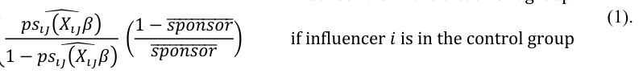

NOTE: contains mathematical notation; text above is the PDF text layer and symbols may be mis-extracted. Image shows the original.

We validated the effectiveness of the DFL reweighting method by confirming that the weighted

treatment and control groups were comparable on 𝑋!". We computed the standardized difference to assess

the balance of covariates following the matching process (Rubin 2001, Austin 2011). This metric is

computed as the difference between the means of the treatment group, 𝑋<sup>'</sup>%&'(%)'*%, and the means of the

control group, 𝑋<sup>'</sup>+,*%&,- , normalized by the sample variance difference between the treatment group

(𝑠%&'(%)'*%

**equation / math rendering (image)**

NOTE: contains mathematical notation; text above is the PDF text layer and symbols may be mis-extracted. Image shows the original.

/ ) and the control group (𝑠+,*%&,-

/ ). The smaller the standardized differences, the smaller the data

imbalance. There is no strict cutoff in determining whether the weighted treatment and control groups are

comparable enough, but as a rule of thumb, standardized differences of < 0.20 are generally considered

very small, and those > 0.60 are considered large (Cohen 2013, McCaffrey et al. 2013). As detailed in Web

Electronic copy available at: https://ssrn.com/abstract=4071188

Page 21

21

Appendix Section D, across *all* covariates, DFL weighting effectively reduced the data imbalances,

resulting in smaller standardized differences in the weighted sample than the raw sample. Notably, the

absolute values of the standardized differences for all covariates are well < 0.2 (common criteria for “very

small data imbalance”), with approximately 90% of covariates (i.e., 41/47 variables) in the weighted sample

well < 0.1 (an indication of negligible data imbalance; see discussion in Austin and Stuart 2015). Hence,

our weighting strategy created a matched sample that effectively mitigated the significant imbalances in the

covariates that existed in the raw sample.

Lastly, the matching process dealt with an extensive set of *observed* factors as possible confounders.

However, we could not exclude *unobservables* that might have influenced both the treatment status and the

influencer’s reputation simultaneously. To address this concern, we implemented a sensitivity test using

the Rosenbaum bounds analysis. As discussed in Section 4.1.1 and Web Appendix Section E, the DFL-

matched sample led to results that were fairly robust to hypothetical *unobservables*.

*3.3. Estimator of the Reputation Impact of Brand Sponsorship*

Equation (2) describes our main empirical specification:

𝑃𝑜𝑠𝑡_𝑅𝑒𝑝𝑢𝑡𝑎𝑡𝑖𝑜𝑛!" = 𝐶𝑜𝑛𝑠𝑡𝑎𝑛𝑡+ 𝛽∙𝑆𝑝𝑜𝑛𝑠𝑜𝑟𝑠ℎ𝑖𝑝!" + 𝛾∙𝐶𝑜𝑛𝑡𝑟𝑜𝑙𝑠!" + 𝑀𝑜𝑛𝑡ℎ!" + 𝜀!" (2), where 𝑃𝑜𝑠𝑡_𝑅𝑒𝑝𝑢𝑡𝑎𝑡𝑖𝑜𝑛!" is the reputation of influencer *i* one period (one period is three days) after

**equation / math rendering (image)**

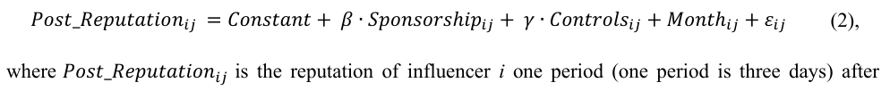

NOTE: contains mathematical notation; text above is the PDF text layer and symbols may be mis-extracted. Image shows the original.

posting video *j*. 𝑆𝑝𝑜𝑛𝑠𝑜𝑟𝑠ℎ𝑖𝑝!" equals 1 if influencer *i*’s video *j* is sponsored; otherwise, 0. The coefficient

of interest is 𝛽, which represents the main effect of posting a sponsored video *j* relative to posting a similar

organic video on the reputation of influencer *i*. We also controlled for an extensive set of factors in

𝐶𝑜𝑛𝑡𝑟𝑜𝑙𝑠!", including influencer *i*’s characteristics (e.g., reputation three days *prior to* video posting,

𝑃𝑟𝑒_𝑅𝑒𝑝𝑢𝑡𝑎𝑡𝑖𝑜𝑛!" ) and video *j*’s characteristics (e.g., the video characteristics used in the matching

process and audience engagement variables). 𝑀𝑜𝑛𝑡ℎ!" is the month fixed effect and captures the possible

seasonal factors (e.g., audiences might be more active in summertime). Equation (2) does not include

influencer fixed effects because they would be perfectly colinear with sponsorship status. As described in

Section 3.1, in constructing the matched sample, we excluded organic videos posted by sponsored

Electronic copy available at: https://ssrn.com/abstract=4071188

Page 22

22

influencers from the matched sample. We additionally controlled for the influencer’s posting behavior in

Equation (2), including the mean and variance of the influencer’s video characteristics over time and the

number of days since the influencer’s last posting. Lastly, we standardized all the video characteristics and

log-transformed all count variables, including the reputation measure.

Equation (2) identifies the effects of brand sponsorship on influencer reputation through two

differences. The first difference is the change in influencer reputation from before to after posting a

*sponsored* video (𝑑0), while the second difference is the change in influencer reputation from before to after

posting an *organic* video (𝑑1). The reputation change is captured in Equation (2), which used the reputation

after a video posting (𝑃𝑜𝑠𝑡_𝑅𝑒𝑝𝑢𝑡𝑎𝑡𝑖𝑜𝑛!") as the dependent variable while controlling for the influencer’s

pre-posting reputation (𝑃𝑟𝑒_𝑅𝑒𝑝𝑢𝑡𝑎𝑡𝑖𝑜𝑛!", which is included in 𝐶𝑜𝑛𝑡𝑟𝑜𝑙𝑠!").<sup>13</sup> The treatment effect of

brand sponsorship on influencer reputation was then identified by computing the difference between the

aforementioned differences, 𝑑0 and 𝑑1. In this identification, it is critical that 𝑑0 is a counterfactual of 𝑑1;

that is, the videos and influencers in the two conditions are comparable. Comparability was achieved by the

DFL matching process, where we constructed similar influencer-video pairs (see Section 3.2). In summary,

we identified the treatment effect by assessing the relative change in reputation when an influencer posts a

sponsored video as opposed to the counterfactual situation when a similar influencer posts a similar organic

video.

4. *RESULTS*

*4.1. Main Effect of Posting a Sponsored (vs. Organic) Video on Influencer Reputation*

Table 3 reports the results of estimating our main model in Equation (2). In column (1), we estimate the

model in the sample matched using DFL reweighting (as our main model); in column (2), we estimate the

13 In Equation (2), the differences are implicitly captured by controlling for 𝑃𝑟𝑒_𝑅𝑒𝑝𝑢𝑡𝑎𝑡𝑖𝑜𝑛!". In Web Appendix Section B.1, we explicitly computed 𝑑# and 𝑑$ by using the difference between 𝑃𝑜𝑠𝑡_𝑅𝑒𝑝𝑢𝑡𝑎𝑡𝑖𝑜𝑛!" and 𝑃𝑟𝑒_𝑅𝑒𝑝𝑢𝑡𝑎𝑡𝑖𝑜𝑛!" for the same video as dependent variable. The alternative model specification yielded consistent results.

Electronic copy available at: https://ssrn.com/abstract=4071188

Page 23

23

model in the sample matched using PSM (as a robustness test). The results are similar between the two

columns, which suggests that the findings are robust to the matching method. We focus on the results in

column (1) for the rest of this section.

The estimated coefficient of the treatment status indicator, 𝑆𝑝𝑜𝑛𝑠𝑜𝑟𝑠ℎ𝑖𝑝!" , was negative and

significant (*b* = −0.00194, *p* < 0.001), suggesting a *reputation-burning* effect, in which posting a sponsored

video, as compared with posting an equivalent organic video (i.e., with similar video features), cost

influencers 0.19% of their subscribers. Intuitively, as an influencer’s fan base declines, views of their later

videos will also decrease, holding everything else constant. Given that YouTube influencers make revenues

based on their number of views, a back-of-the-envelope calculation suggests that the treatment effect of

posting a single sponsored video translates into a loss of around 79,800 views, which is worth

approximately $1,436.40 in annual income.<sup>14</sup>

Is the economic harm of the reputation loss balanced out by the commission fee for the sponsored

content? The commission fee varies widely across platforms and by the number of subscribers.<sup>15</sup> For a

YouTube influencer with approximately 1.18 million subscribers, which is the median of our sample,

brands pay an average of approximately $23,600 per sponsored video. *Prima facie*, the revenue earned from

the sponsorship appears to outweigh the cost of reputation harm. However, brands pay commissions as

lump-sum payments, while the reputation harm caused by one sponsored post may have lasting effects. The

average influencer in our sample had been active for more than six years as of July 2020, so the lifetime

14 In our data, an influencer on average posts 150 videos a year. For a back-of-the-envelope calculation, consider an influencer with 1,180,000 subscribers (the median of our sample). The influencer receives 280,000 views on average for each video. Thus, assuming that reputation burning has the same effect on the video views, posting a sponsored video, as opposed to posting a similar organic video, would cause an influencer to lose 79,800 views annually (= 0.19% loss in views ´ 150 videos per year ´ 280,000 views per video). It follows that the annual loss of 79,800 viewership translates to 79,800 views per video ´ 0.018 USD per view = $1436.40. Note that YouTube influencers are paid according to their video views (through YouTube’s payment and displayed ad), with the current rate being approximately $0.018 per view (https://influencermarketinghub.com/how-much-do-youtubers-make/). 15 According to DigitalMarketing.org, Instagram influencers charge anywhere between $75 and $3,000 per sponsored Instagram post. YouTube influencers are usually more expensive, as they are paid $2,000 on average per 100,000 subscribers.

Electronic copy available at: https://ssrn.com/abstract=4071188

Page 24

24

effect of posting *one* sponsored post can accumulate to approximately $8,618 (= $1,436.40 ´ 6).<sup>16</sup> Though

some other platforms may not compensate influencers like YouTube does, losing a number of subscribers

is still costly for influencers because it will impact their ability to obtain profitable offers from brands in

the future.

To counterbalance the *reputation-burning effect* of brand sponsorship, influencers may strive to

enhance video quality while creating sponsored videos, but this is not an easy task. For example, the

estimated coefficient of 𝑉𝑖𝑑𝑒𝑜_𝐿𝑒𝑛𝑔𝑡ℎ!" is negative and significant (*b* = −0.000294, p < 0.05), which

suggests that holding everything else constant, an influencer would need to create a video with a reduction

easy task because the influencer would need to deliver the same effectiveness of content and messages in a

much shorter timeframe. Similarly, the estimated coefficients of 𝑊𝑜𝑟𝑑_𝐶𝑜𝑢𝑛𝑡_𝐷𝑒𝑠𝑐𝑟𝑖𝑝𝑡𝑖𝑜𝑛!" and

𝑆𝑎𝑡𝑢𝑟𝑎𝑡𝑖𝑜𝑛!" imply that to bear out the harm of brand sponsorship on their reputation, an influencer would

need to write 3.83 standard deviations (= 0.00194/0.000506) more content in video description or to have

visual scenes that are 3.63 standard deviations (= 0.00194/0.000534) more vivid and colorful, holding

everything else constant. Alternatively, influencers might take proactive actions to recover their reputations

after posting sponsored videos, but these actions are costly on their own. For example, an influencer might

send gifts to subscribers or post more frequent, high-quality organic videos (at the cost of scripting, filming,

editing, and more). However, the same reputation-building actions could be taken by influencers who had

never posted a sponsored video, and the benefit might be larger in this case.

To clarify, we do not claim that influencers should decline all brand sponsorships due to the

*reputation-burning effect*. However, by quantifying the economic impact of reputation burning, we provide

a baseline that influencers can use to think about the hidden economic trade-off involved in sponsorship

16 We recognize that many influencers in our dataset continued to post after July 2020, so the average duration of a top-tier influencer’s career is probably longer than six years. We adopted a conservative estimate of a YouTube influencer’s lifetime by using six years.

Electronic copy available at: https://ssrn.com/abstract=4071188

Page 25

[output not shown]

NOTE: table converted from PDF layout to HTML text; cell boundaries are reconstructed. See PDF if exact alignment matters.

offers. Furthermore, influencers are appealing to brands precisely because they can engage a large audience.

If an influencer cannot sustain or grow their fan base like other influencers, then the focal influencer may

eventually lose sponsorship to a competing influencer (i.e., someone in the same category who has been

able to grow their reputation). In addition, influencers are valuable to platforms because they engage large

segments of the active user population. If many influencers are damaging their reputations via sponsorship,

the platform might be worse off in the long run as overall audience engagement decreases.

**Table 3. Main Effect of Posting a Sponsored (vs. Organic) Video on the Influencer**’**s Reputation**

Electronic copy available at: https://ssrn.com/abstract=4071188

Page 26

26

| Loud _Std -0 .000490 | (0000492) . | 0000168 (0000352) - . . |
| --- | --- | --- |
| Pitch _Mean -0 .00174** | (0000563) . | 0000451 (0000917) - . . |
| Pitch Std 000102** _ . | (0000385) . | 0000688 (0000543) . . |
| Verbosity Mean 000110* _ . | (0000476) . | 0000963 (0000791) . . |
| Verbosity _Std -0 .0000436 | (0000311) . | 0000501 (0000440) - . . |
| Loudvar Mean 000222** _ . | (0000706) . | 0000599 (000116) . . |
| Loudvar _Std -0 .000448 | (0000327) . | 00000505 (0000330) - . . |
| VisualAesthetics |  |  |
| Foreground _Motion _Area -0 .000325* | (0000158) . | 0000225 (0000140) . . |
| Motion _Magnitude -0 .000190 | (0000167) . | 0000241 (0000291) - . . |
| Motion Direction 0000213 _ . | (0000138) . | 0000369 (0000256) . . |
| Warm _Hue _Proportion -0 .000413* | (0000176) . | 0000166 (0000148) - . . |
| Saturation 0000534* . | (0000250) . | 0000312 (0000318) . . |
| Brightness -0 .000532 | (0000308) . | 00000596 (0000188) . . |
| Cob -0 .000334* | (0000132) . | 0000108 (0000213) - . . |
| Clarity 0000133 . | (0000282) . | 00000180 (0000194) . . |
| TheInfluencer’sEmotionsandAppearance |  |  |
| Face (Presence of Face) -0 .00354* | (000138) . | 000317* (000144) - . . |
| FaceCount 0000444* . | (0000193) . | 00000355 (0000294) . . |
| Smile 0000215 . | (0000205) . | 0000383 (0000232) . . |
| FacialEmotion |  |  |
| Anger -0 .000241 | (0000188) . | 0000137 (0000140) - . . |
| Happiness -0 .000764* | (0000388) . | 0000488 (0000263) - . . |
| Neutrality -0 .000699 | (0000413) . | 0000324 (0000382) - . . |
| Sadness -0 .000331 | (0000176) . | 0000258 (0000207) - . . |
| Surprise -0 .000292 | (0000216) . | 0000171 (0000169) - . . |
| Image Quality of the Face -0 .000384 | (0000236) . | 0000267 (0000186) . . |
| FacialAttractiveness(Female) 0000875 . | (000224) . | 0000286 (000154) . . |
| Facial Attractiveness (Male) -0 .000323 | (000205) . | 0000456 (000151) . . |
| FacialSkinStatus |  |  |
| Health 0000422 . | (0000281) . | 0000151 (0000234) - . . |
| Stain -0 .000107 | (0000204) . | 000000873 (0000170) - . . |
| Dark _Circle -0 .000265 | (0000147) . | 00000418 (0000102) . . |
| Acne 0000112 . | (0000111) . | 00000277 (0000144) . . |
| Face Blur Condition -0 .000344 | (0000204) . | 0000133 (0000166) . . |
| Constant 00777*** . | (000676) . | 00877*** (000754) . . |
| Observations 63880 |  | 10732 |
| AIC 8555659 - . |  | 633843 - . |
| BIC 8543875 - . |  | 624305 - . |

NOTE: table converted from PDF layout to HTML text; cell boundaries are reconstructed. See PDF if exact alignment matters.

Electronic copy available at: https://ssrn.com/abstract=4071188

Page 27

27

Note: Column (1) shows estimates from the sample matched using DFL reweighting, and column (2) shows estimates from the sample matched using PSM. All video features were standardized, and count variables were logtransformed. *Channel_preceding_subscribers* is the influencer’s reputation one period (three days) before posting a video (i.e., 𝑃𝑟𝑒_𝑅𝑒𝑝𝑢𝑡𝑎𝑡𝑖𝑜𝑛!"). Fewer observations were made in the PSM sample because we used one-to-four matching and dropped all the unmatched observations. We also controlled for the mean and variance of the influencers’ video characteristics but do not report them here owing to space limitations. For the full regression table, please refer to Web Appendix Section F. Standard errors are in parentheses and clustered at the influencermonth level. *p < 0.05; **p < 0.01; ***p < 0.001

*4.1.1. Rosenbaum Bounds Analysis: Assessing Sensitivity to Unobservables*

The identification of the treatment effect in Equation (2) was based on the sample that was matched on the

observed characteristics. However, the DFL reweighting strategy, like all matching and weighting methods,

cannot match samples based on unobserved characteristics. A potential concern arises if there are

*unobservables* that affect both the decision to post sponsored content and the outcome of that decision,

which would bias the estimated treatment effect. For example, if influencers tend to post sponsored videos

when they are under financial stress, which affects the way influencers interact with their subscribers and

worsens their reputations, then we would overestimate the treatment effect by misattributing the impact of

financial stress on influencer reputation.

Although the presence of an *unobservable* is not empirically testable, we can assess the robustness

of our main results to *hypothetical unobservables* by conducting a Rosenbaum bounds analysis (Rosenbaum

2002). In brief, consider two units, *i* and *j*, with observed covariates 𝑋! and 𝑋" and unobserved covariates

𝑈! and 𝑈". The selection process (i.e., the probability of posting a sponsored video) is written as follows:

_<sup>𝑃𝑟𝑜𝑏</sup><sup>!</sup><sup>(𝑆𝑝𝑜𝑛𝑠𝑜𝑟𝑠ℎ𝑖𝑝= 1|𝑋</sup><sup>!</sup><sup>, 𝑈</sup><sup>!</sup><sup>) = 𝑓(𝛽𝑋</sup><sup>!</sup><sup>+ 𝛾𝑈</sup><sup>!</sup><sup>)</sup>

**equation / math rendering (image)**

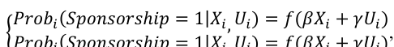

NOTE: contains mathematical notation; text above is the PDF text layer and symbols may be mis-extracted. Image shows the original.

𝑃𝑟𝑜𝑏"(𝑆𝑝𝑜𝑛𝑠𝑜𝑟𝑠ℎ𝑖𝑝= 1|𝑋", 𝑈") = 𝑓(𝛽𝑋" + 𝛾𝑈")<sup>,</sup>

**equation / math rendering (image)**

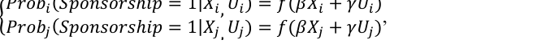

NOTE: contains mathematical notation; text above is the PDF text layer and symbols may be mis-extracted. Image shows the original.

(3), where 𝛾 indicates the influence of unobserved variables 𝑈 on the treatment assignment process

𝑃𝑟𝑜𝑏!(𝑆𝑝𝑜𝑛𝑠𝑜𝑟𝑠ℎ𝑖𝑝= 1). Assuming a logistic functional form for 𝑓(∙), we write the odds for each unit

as

**equation / math rendering (image)**

NOTE: contains mathematical notation; text above is the PDF text layer and symbols may be mis-extracted. Image shows the original.

**equation / math rendering (image)**

NOTE: contains mathematical notation; text above is the PDF text layer and symbols may be mis-extracted. Image shows the original.

**equation / math rendering (image)**

NOTE: contains mathematical notation; text above is the PDF text layer and symbols may be mis-extracted. Image shows the original.

*=*

**equation / math rendering (image)**

NOTE: contains mathematical notation; text above is the PDF text layer and symbols may be mis-extracted. Image shows the original.

**equation / math rendering (image)**

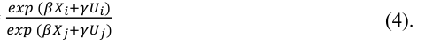

NOTE: contains mathematical notation; text above is the PDF text layer and symbols may be mis-extracted. Image shows the original.

Electronic copy available at: https://ssrn.com/abstract=4071188

Page 28

28

If the two units have the same observed covariates but differ on unobserved covariates (i.e., 𝑋! =

𝑋" and 𝑈! ≠ 𝑈"), the OR becomes:

**equation / math rendering (image)**

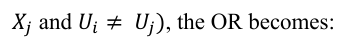

NOTE: contains mathematical notation; text above is the PDF text layer and symbols may be mis-extracted. Image shows the original.

**equation / math rendering (image)**

NOTE: contains mathematical notation; text above is the PDF text layer and symbols may be mis-extracted. Image shows the original.

#$%&! '(#$%&!

**equation / math rendering (image)**

NOTE: contains mathematical notation; text above is the PDF text layer and symbols may be mis-extracted. Image shows the original.

#$%&" '(#$%&"

**equation / math rendering (image)**

NOTE: contains mathematical notation; text above is the PDF text layer and symbols may be mis-extracted. Image shows the original.

*=* 𝑒𝑥𝑝(𝛾(𝑈! −𝑈")) (5).

**equation / math rendering (image)**

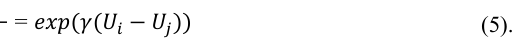

NOTE: contains mathematical notation; text above is the PDF text layer and symbols may be mis-extracted. Image shows the original.

Hence, both individual units have the same probability of posting a sponsored video (i.e., with the

same propensity scores) if 𝑈! = 𝑈" (i.e., the two units have identical *unobservables*) or if 𝛾= 0 (i.e., the

unobserved covariates have no influence on the likelihood of posting a sponsored video). In other words,

unobserved factors do not introduce a hidden selection bias into our estimated effect if and only if the OR

is 1. Otherwise, a potential bias may arise because the matching method would match units *i* and *j*, which

have similar observables but differ in their actual propensity scores because of *unobservables*.

The Rosenbaum bounds analysis evaluates how inferences about treatment effects would change

in the presence of 𝑈! − 𝑈"≠ 0, by varying values of 𝛾 and 𝑈! − 𝑈" (and, hence, varying the OR). Following

Rosenbaum (2002), we assumed for simplicity a binary unobservable variable: 𝑈∈ 0, 1. Rosenbaum (2002;

see details on page 107) showed that the OR is bounded by *Gamma*, which equals to exp(𝛾):

**equation / math rendering (image)**

NOTE: contains mathematical notation; text above is the PDF text layer and symbols may be mis-extracted. Image shows the original.

𝑃𝑟𝑜𝑏! 1 −𝑃𝑟𝑜𝑏!

**equation / math rendering (image)**

NOTE: contains mathematical notation; text above is the PDF text layer and symbols may be mis-extracted. Image shows the original.

𝑃𝑟𝑜𝑏" 1 −𝑃𝑟𝑜𝑏" < 𝑒𝑥𝑝(𝛾) = 𝐺𝑎𝑚𝑚𝑎 (6).

**equation / math rendering (image)**

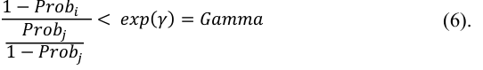

NOTE: contains mathematical notation; text above is the PDF text layer and symbols may be mis-extracted. Image shows the original.

For Equation (6), Rosenbaum (2002; details are on page 110) developed a Wilcoxon signed-rank

statistic *T* for the matched pairs {𝑖*,* 𝑗}, where the outcome for the treatment is greater than the outcome for

the control. According to Rosenbaum’s (2002) proposition 13, for a given value of 𝛾, if the treatment has a

null effect, the unknown null distribution of *T* is bounded by two distributions of 𝑇<sup><</sup> and 𝑇<sup>4</sup>. Then, at each

𝑒𝑥𝑝(𝛾), we calculate a statistical significance level “p value” (both sig+ and sig−) and the 95% confidence

interval based on the Wilcoxon signed-rank tests and the distributions of 𝑇<sup><</sup> and 𝑇<sup>4</sup>. Details on how to

implement the Wilcoxon signed-rank tests are in Web Appendix Section E.

In Table 4, the column “Significance Level (sig+, sig-)” reports the estimated p values, and the

column “95% Confidence Interval” reports the estimated 95% CI of the point estimate. Both columns report

Electronic copy available at: https://ssrn.com/abstract=4071188

Page 29

29

results when setting the influence of the hypothetical unobservable bias to 𝑒𝑥𝑝(𝛾), denoted as *Gamma*. We

increased *Gamma* in steps of 0.05, starting from 1, and reported the estimated p values and intervals under

each *Gamma*. A larger *Gamma* suggests a more robust result for hypothetical unobserved confounding

factors, as it would require a larger influence of hypothetical *unobservables* to nullify the treatment effect.

**Table 4. Sensitivity Analysis: Rosenbaum Bounds Test**

| Gamma | SignificanceLevel | 95%ConfidenceInterval |
| --- | --- | --- |
| (=𝒆𝒙𝒑(𝜸)) | sig+ sig- | CI+ CI - |
| 1 | 0 0 | 567000 459958 - - |
| 105 . | 0 0 | 611375 415166 - - |
| 11 . | 0 0 | 653625 371908 - - |
| 115 . | 0 0 | 694184 330031 - - |
| 12 . | 0 0 | 733346 289525 - - |
| 125 . | 0 0 | 770842 250185 - - |
| 13 . | 0 0 | 807116 211596 - - |
| 135 . | 0 140E 13 . - | 842212 173750 - - |
| 14 . | 0 460E 10 . - | 876114 136708 - - |
| 145 . | 0 310E 07 . - | 909073 100375 - - |
| 15 . | 0 000005 . | 941056 645833 - - . |
| 155 . | 0 0002308 . | 971908 296186 - - . |
| 16 . | 0 003531 . | 100E+06 518747 - . . |
| 165 . | 0 0207489 . | 100E+06 392766 - . . |
| 17 . | 0 0558735 . | 110E+06 726842 - . . |

NOTE: table converted from PDF layout to HTML text; cell boundaries are reconstructed. See PDF if exact alignment matters.

the “sig-” and “95% Confidence Interval” columns. These columns lead to the same conclusion. The critical

level of *Gamma* at which our *reputation-burning effect* might be nullified is 1.6, as this is where the 95%

In other words, the estimated negative treatment effect would be nullified if there were hypothetical

*unobservables* (1) that affected the treatment assignment and influencer reputation at the same time and (2)

that are so large that they could alter the *OR* by 1.6. Note that these results represent the worst-case scenarios

Electronic copy available at: https://ssrn.com/abstract=4071188

Page 30

30

and do not imply that such hypothetical *unobservables* exist and are large enough to nullify the treatment

effect.

How good is the result of *Gamma* = 1.6? Our estimated *Gamma* value of 1.6 is at the upper end of

the range reported in the literature (1.2–1.6; DiPrete and Gangl 2004; Manchanda, Packard, and

Pattabhiramaiah 2015; Sun and Zhu 2013; Zhang et al. 2021), which implies that our results are on par with,

if not more robust than, those reported in the previous studies. As the Rosenbaum bounds analysis provided

a lower bound of confidence for the worst-case scenario, we are fairly confident that our results are robust

to hypothetical unobserved confounders.

In addition, we followed Bharath et al. (2011) and provide an interpretation of the obtained value

of *Gamma*. Specifically, we assessed how much change in the observed variables is required to change the

*OR* by a factor of 1.60. We found that it would need an implausibly large amount of change in the observed

video or influencer characteristics. For example, the influencer’s reputation prior to video posting

(*Channel_Preceding_Subscribers*) would need to increase by 2.42 standard deviations (translating to 4.45

million subscribers) to change the *OR* by a factor of 1.60. In Web Appendix Section E, we present the

details of the Rosenbaum bounds analysis results and their interpretations.

*4.1.2 Additional Robustness Tests and Ruling Out Alternative Explanations*

Our results are robust to alternative model specifications, including using both the *relative* and *absolute*

changes in influencer reputation as alternative dependent variables (see Web Appendix Section B.1). In a

robustness analysis, we included organic videos of sponsored influencers and obtained similar results (see

Web Appendix Section B.2). An analysis of views received by sponsored and organic videos suggests that

brand sponsorship alone would not affect the influencer’s ability to gain traffic; that is, we did not find

evidence that YouTube’s video recommendation algorithm explains the documented treatment effect by

directing more traffic and thus more prospective subscribers to organic videos (see Web Appendix Section

B.3). A series of analyses that controlled for brand and video topic fixed effects excluded the alternative

explanation that the *reputation-burning effect* was driven by systematic differences in the characteristics of

Electronic copy available at: https://ssrn.com/abstract=4071188

Page 31

31

brands or topics featured in sponsored and organic videos (see Web Appendix Sections B.4 and B.5). In

addition, we conducted two analyses where we did not control for video engagement or video characteristics

and consistently obtained a negative and significant *reputation-burning effect* (see Web Appendix Section

C.3). Finally, we conducted a placebo test and validated that the *reputation-burning effect* was attributed to

the influencers’ sponsored videos, rather than any potential disproportionate reputation growth between the

treated and control influencers (Web Appendix Section B.6).

*4.2. Heterogeneous Effect of the Influencer’s Audience Size*

Experticity (2016) and Barker (2019) showed that sponsored content is perceived as more authentic and

trustworthy when posted by influencers with smaller audiences (i.e., fewer subscribers). We reason that the

influencer’s audience size might moderate the effect of sponsorship on reputation. We added an interaction

term, 𝑃𝑟𝑒_𝑅𝑒𝑝𝑢𝑡𝑎𝑡𝑖𝑜𝑛!" ∙𝑆𝑝𝑜𝑛𝑠𝑜𝑟𝑠ℎ𝑖𝑝!", to the model in Equation (2), where 𝑃𝑟𝑒_𝑅𝑒𝑝𝑢𝑡𝑎𝑡𝑖𝑜𝑛!" is

**equation / math rendering (image)**

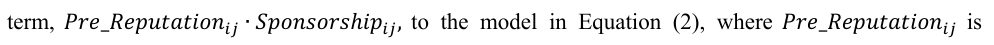

NOTE: contains mathematical notation; text above is the PDF text layer and symbols may be mis-extracted. Image shows the original.

influencer *i*’s (logged) audience size prior to posting video *j*. The coefficient of the interaction term, 𝜇,

captures the extent to which audience size moderates the treatment effect. In Table 5, 𝜇 is negative and

significant (*b* = −0.00125, *p* < 0.05), indicating that the reputation-burning effect is stronger for influencers

with larger audiences. That is, for every 10% increase in the influencer’s audience size, the influencer’s

On the basis of our back-of-envelope calculation of the annual income loss from posting a single sponsored

video, every 10% increase in audience size leads to an additional annual revenue loss of $91 (= 6.32% ´

$1,436.40).

**Table 5. Heterogeneity by Influencer Audience Size**

| VARIABLES | ESTIMATES | SE . . |
| --- | --- | --- |
| Sponsorship | 00159* . | (000745) . |
| SponsorshipXLog Channel Preceding Subscribers _ _ _ | 000125* - . | (0000507) . |
| InfluencerCharacteristics |  |  |
| Log Channel Preceding Subscribers _ _ _ | 0996*** . | (0000527) . |
| Log Days Since First Posting _ _ _ _ | 000426*** - . | (0000430) . |
| Log Channel Title Length _ _ _ | 000143** . | (0000522) . |
| Log Weekly Video Number _ _ _ Log Days from Last Posting _ _ _ _ | 0000289 - . 000164*** - . | (0000353) . (0000223) . |

NOTE: table converted from PDF layout to HTML text; cell boundaries are reconstructed. See PDF if exact alignment matters.

Electronic copy available at: https://ssrn.com/abstract=4071188

Page 32

[output not shown]

NOTE: table converted from PDF layout to HTML text; cell boundaries are reconstructed. See PDF if exact alignment matters.

32

Female 0.000218 (0.000408) Log_Age 0.00117** (0.000401) Constant 0.0560*** (0.00650) Observations 63880 AIC -855587.0 BIC -854399.5 Note: The model was estimated on the matched sample using DFL reweighting. Our dependent variable was log-transformed. *Channel_preceding_subscribers* is the influencer’s reputation one period (three days) before posting a video (i.e., 𝑃𝑟𝑒_𝑅𝑒𝑝𝑢𝑡𝑎𝑡𝑖𝑜𝑛!") and was also log-transformed. We controlled for video engagement and video features as in Table 3 and controlled for the mean and variance of influencers’ video characteristics but do not report the coefficients owing to limited space. For the full regression table, please refer to Web Appendix Section F. Standard errors are in parentheses and clustered at the influencer-month level. *p < 0.05; **p < 0.01; ***p < 0.001

We reason that influencers with smaller audiences have tighter communities or network ties and

form “a more intimate and meaningful relation” with their subscribers (Segura 2018; Wies, Bleier, and

Edeling 2022: 12). If so, then smaller (vs. larger) audiences might be more receptive to sponsored content.

For example, subscribers within a smaller audience might perceive a sponsored video as an achievement,

whereas subscribers within a larger audience might perceive the same sponsored video as a brand

endorsement, motivated primarily by monetary interests and therefore inauthentic and untrustworthy.

We tested this possibility by analyzing the audience’s response to the post (reflected in the number

of likes and comments; Ershov and Mitchell 2020; Rajaram and Manchanda 2020) and trust in the post

and/or influencer (reflected in the comment text; Tabor 2020). An influencer’s audience size may affect the

variables of interest, so we operationalized them as rates (i.e., we divided the raw numbers of likes, raw

numbers of comments, and trust measured by the number of subscribers), which is a common practice when

measuring content performance (Keyhole 2020). We examined whether and how the audience response

differs between sponsored and organic videos, and whether the *difference in responses* varies with the

influencer’s audience size.

We collected the number of likes, number of comments, and comment text for the 63,880 matched

videos in our sample. Following Rajaram and Manchanda (2020), we analyzed the top 300 comments.<sup>17</sup>

17 Some comments have replies from other audience members or from the influencer themselves; each reply counts as a separate record. The average video in our sample has 434.4 comments. The comments are ranked by YouTube’s proprietary algorithm on the basis of timeliness and popularity (https://stackoverflow.com/questions/27781751/whatis-youtube-comment-system-sorting-ranking-algorithm).

Electronic copy available at: https://ssrn.com/abstract=4071188

Page 33

33

We found valid comments for 59,959 of the 63,880 matched videos in our sample,<sup>18</sup> yielding a total of

7,506,942 records. We used the Emotion Lexicon from the National Research Council (NRC; see

Mohammad and Turney 2013) to analyze the emotions reflected in the comment text. The NRC Emotion

Lexicon is a list of English words annotated by crowd-sourced workers. The lexicon includes the strength

of the association between each word and eight basic emotions: anger, fear, anticipation, trust, surprise,

sadness, joy, and disgust. We focused on *trust* because the trustworthiness of influencers is thought to be

central to the effectiveness of influencer marketing and can plausibly vary with the influencer’s audience

size and be harmed by sponsorship (Audrezet, de Kerviler, and Moulard 2020; Tabor 2020). Figure 3 shows

Web Appendix Section A.2.

(1) (2)

We ranked the influencers by their subscriber counts and created three categories: small audience

(bottom quartile), large audience (top quartile), and medium audience (middle two quartiles). Figure 4

visualizes the estimated effects of sponsorship on the three audience response variables for medium- and

large-audience influencers relative to the baseline group of small-audience influencers. For all three

variables, we found that the difference in audience response to the sponsored and organic videos was greater

for medium- and large-audience influencers than for small-audience influencers;<sup>19</sup> the differences are

slightly more pronounced for large-audience influencers than for medium-audience influencers. Figure 4

18 Of the original 63,880 videos, 3,921 videos received no comments, disabled the comment function, or received only comments with emojis and scrambled characters. 19 In the introduction, we compared the raw numbers of likes and comments between the sponsored and organic videos. We regressed the normalized numbers of likes and comments on sponsorship and the interactions between sponsorship and categorized audience size, influencer characteristics, and video features.

Electronic copy available at: https://ssrn.com/abstract=4071188

Page 34

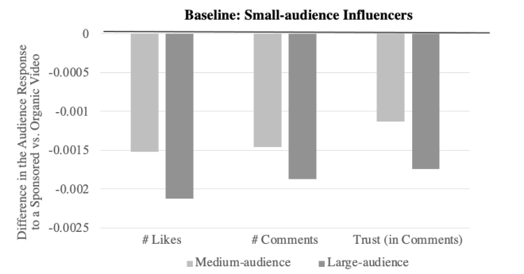

NOTE: figure/graphic rendered as an image from the PDF; its content is not machine-readable text. Caption (if any) follows as the next block.

34

supports our argument that the *reputation-burning effect* is stronger for influencers with larger audiences

because larger audiences, relative to smaller ones, are less trusting and less engaged with sponsored videos

than with similar organic videos. These findings can have consequential implications for brands that suggest

that influencers with larger audiences may not always be the optimal choice in terms of favorable audience

responses to brand-sponsored content.

**Figure 4. Influencer Audience Size Moderates the Audience Response to Sponsored Videos**

#### **Compared with Organic Videos**

*4.3. Heterogeneous Effect by Influencer-Video Fit*

We investigated *influencer-video fit* as another possible moderator of the reputation-burning effect because

*fit* is important in celebrity endorsements (Kirmani and Shiv 1998; Knoll and Matthes 2017). Specifically,

the “match-up hypothesis” states that a high celebrity-sponsorship *fit* leads to more-positive brand

evaluations and stronger celebrity endorsement effects (Choi and Rifon 2012). For example, if an influencer

usually shares her expertise in hair styling, then her subscribers might be more receptive to a sponsored

video about a hair styling product (high fit) than to a sponsored video about a lipstick (low fit).

We use *doc2vec*, an unsupervised algorithm that learns fixed-length feature representations (i.e.,

“embeddings”) from texts (Quoc and Mikolov 2014) in order to extract the content of each video from its

Electronic copy available at: https://ssrn.com/abstract=4071188

Page 35

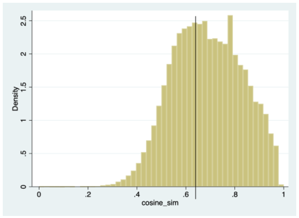

NOTE: figure/graphic rendered as an image from the PDF; its content is not machine-readable text. Caption (if any) follows as the next block.

35

title and description. <sup>20</sup> To characterize each influencer’s “usual” content, we calculated the content

embedding for each of their past videos, including both sponsored and organic videos, and we averaged

them. To measure the fit between the influencer and the focal video, we calculated the cosine similarity

between the focal video’s content embedding and the influencer’s average content embedding, regardless

of the sponsorship status of the focal video. Technical details about the measures and examples are provided

in Web Appendix Section A.3. Figure 5 shows the distribution of the *influencer-video fit* variable in our

sample. The mean of the distribution was 0.69, and the standard deviation was 0.14.

**Figure 5. Distribution of *Influencer-Video Fit*** Note: The vertical line indicates where *influencer-video fit* is 0.63, 35<sup>th</sup> percentile of the

influencer-video *fit* variable.

Equation (7) includes the linear and quadratic terms of 𝑆𝑖𝑚𝑖𝑙𝑎𝑟𝑖𝑡𝑦!" to the model in Equation (2)

to capture exploration and exploitation behaviors (He and Wong 2004; March 1991). In Equation (8), we

added the interaction terms 𝑆𝑖𝑚𝑖𝑙𝑎𝑟𝑖𝑡𝑦!" ∙𝑆𝑝𝑜𝑛𝑠𝑜𝑟𝑠ℎ𝑖𝑝!" and 𝑆𝑖𝑚𝑖𝑙𝑎𝑟𝑖𝑡𝑦!"

**equation / math rendering (image)**

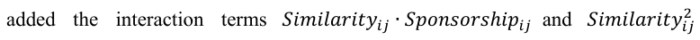

NOTE: contains mathematical notation; text above is the PDF text layer and symbols may be mis-extracted. Image shows the original.

/ ∙𝑆𝑝𝑜𝑛𝑠𝑜𝑟𝑠ℎ𝑖𝑝!". The

**equation / math rendering (image)**

NOTE: contains mathematical notation; text above is the PDF text layer and symbols may be mis-extracted. Image shows the original.

coefficients of the interaction terms, 𝜇@ and 𝜇A, capture the extent to which *influencer-video fit* moderates

the reputation-burning effect.

20 The embedding based on the video title and description captures what the video is about, which is sufficient for our purposes. The embedding cannot speak to the presentation of the influencer and product; future studies could explore advanced algorithms to compute the embedding based on the raw video content.

Electronic copy available at: https://ssrn.com/abstract=4071188

Page 36

36

In column (1) of Table 6, the coefficient of 𝑆𝑖𝑚𝑖𝑙𝑎𝑟𝑖𝑡𝑦!" is positive and significant (*b* = 0.0160, *p*

< 0.05), while the coefficient of 𝑆𝑖𝑚𝑖𝑙𝑎𝑟𝑖𝑡𝑦!"

/ is negative and significant (*b* = −0.0132, *p* < 0.05). The results

suggest that influencers need some degree of consistent content but that over-consistency backfires. This

aligns with the findings of past work on exploration-exploitation and variety-seeking behaviors (He and

Wong 2004; March 1991). In column (2), the coefficients of the interaction terms (𝜇@ = −0.0260, p < 0.05;

𝜇A = 0.0205, p < 0.05) suggest a U-shape moderation effect of the similarity measure on influencer

reputation. In particular, the vertex of the U-shape occurs at a 𝑆𝑖𝑚𝑖𝑙𝑎𝑟𝑖𝑡𝑦!" = 0.63, approximately

representing the 35th percentile of the influencer-video *fit* variable (the 35th percentile is indicated by the

vertical line in Figure 5). The results suggest that the moderation effect of influencer-video *fit* varies across

videos (U-shaped relationship). For example, when the influencer-video *fit* is small (< 0.63), increasing the

*fit* would result in a more negative reputation-burning effect, possibly due to customers’ need for uniqueness

(Abosag et al. 2020). However, once the influencer-video *fit* passes 0.63, the influencer-video *fit* variable

positively moderates the reputation-burning effect, which is consistent with the “match-up hypothesis”

(Kirmani and Shiv 1998). Approximately two-thirds of our sample are on the right side of the U-shape,

where the influencer-video *fit* value is > 0.63. Hence, when promoting a brand, an influencer might consider

creating content that *fits* their style.

As most of our sample is on the right side of the U-shaped curve, the findings suggest that

influencers should strive for consistency overall while including enough variety so that the audience does

not become bored (Chen et al. 2020). However, sponsored content is not a good way to provide variety.

Rather, influencers appear to be better off (in terms of reputation) when sponsored content is consistent

𝑃𝑜𝑠𝑡_𝑅𝑒𝑝𝑢𝑡𝑎𝑡𝑖𝑜𝑛!" *= Constant* + 𝛽∙𝑆𝑝𝑜𝑛𝑠𝑜𝑟𝑠ℎ𝑖𝑝!"+ 𝜇0 ∙𝑆𝑖𝑚𝑖𝑙𝑎𝑟𝑖𝑡𝑦!"+ 𝜇/ ∙𝑆𝑖𝑚𝑖𝑙𝑎𝑟𝑖𝑡𝑦!"

**equation / math rendering (image)**

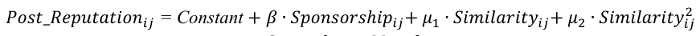

NOTE: contains mathematical notation; text above is the PDF text layer and symbols may be mis-extracted. Image shows the original.

/ + 𝛾∙𝐶𝑜𝑛𝑡𝑟𝑜𝑙𝑠!" + 𝑀𝑜𝑛𝑡ℎ!" + 𝜀!" (7)

**equation / math rendering (image)**

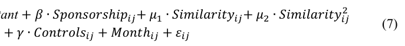

NOTE: contains mathematical notation; text above is the PDF text layer and symbols may be mis-extracted. Image shows the original.

𝑃𝑜𝑠𝑡_𝑅𝑒𝑝𝑢𝑡𝑎𝑡𝑖𝑜𝑛!" = 𝐶𝑜𝑛𝑠𝑡𝑎𝑛𝑡 + 𝛽∙𝑆𝑝𝑜𝑛𝑠𝑜𝑟𝑠ℎ𝑖𝑝!" + 𝜇0 ∙𝑆𝑖𝑚𝑖𝑙𝑎𝑟𝑖𝑡𝑦!" + 𝜇/ ∙ 𝑆𝑖𝑚𝑖𝑙𝑎𝑟𝑖𝑡𝑦!"

**equation / math rendering (image)**

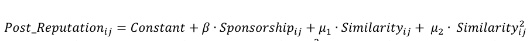

NOTE: contains mathematical notation; text above is the PDF text layer and symbols may be mis-extracted. Image shows the original.

/ + 𝜇@ ∙ 𝑆𝑖𝑚𝑖𝑙𝑎𝑟𝑖𝑡𝑦!" ∙𝑆𝑝𝑜𝑛𝑠𝑜𝑟𝑠ℎ𝑖𝑝!" + 𝜇A ∙ 𝑆𝑖𝑚𝑖𝑙𝑎𝑟𝑖𝑡𝑦!"

**equation / math rendering (image)**

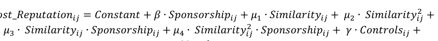

NOTE: contains mathematical notation; text above is the PDF text layer and symbols may be mis-extracted. Image shows the original.

/ ∙𝑆𝑝𝑜𝑛𝑠𝑜𝑟𝑠ℎ𝑖𝑝!" + 𝛾∙𝐶𝑜𝑛𝑡𝑟𝑜𝑙𝑠!" + 𝑀𝑜𝑛𝑡ℎ!" + 𝜀!"

**equation / math rendering (image)**

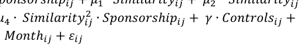

NOTE: contains mathematical notation; text above is the PDF text layer and symbols may be mis-extracted. Image shows the original.

(8)

Electronic copy available at: https://ssrn.com/abstract=4071188

Page 37

37

with their usual content (i.e., when 𝑆𝑖𝑚𝑖𝑙𝑎𝑟𝑖𝑡𝑦!" is high). We reason that influencer-video *fit* mitigates the

reputation-burning effect because the sponsored video may appear more authentic and trustworthy when

on a topic for which the influencer has built credibility and expertise, consistent with the source credibility

model (Sternthal, Dholakia, and Leavitt 1978). Arguably, *fit* depends not only on *what* is promoted but also

on *how* it is promoted. For example, PepsiCo paid the pop singer Bebe Rexha to sample chips and then

sync the flavors with her original music.<sup>21</sup> Although the product itself had a low fit with Rexha’s usual

content, the delivery of the promotion boosted the fit because she created an authentic analogy between

creating music and developing new snack flavors.

**Table 6. Heterogeneity by Influencer-Video Fit**

|  | (1) | (2) |  |
| --- | --- | --- | --- |
| VARIABLES | ESTIMATES SE . . | ESTIMATES | SE . . |
| Sponsorship | 000198*** (0000329) - . . | 000597 . | (000361) . |
| Similarity | 00160* (000655) . . | 00176* . | (000709) . |
| Similarity2 | 00132* (000528) - . . | 00145* - . | (000571) . |
| SponsorshipXSimilarity SponsorshipXSimilarity2 |  | 00260* - . 00205* . | (00122) . (000969) . |
|  | InfluencerCharacteristics |  |  |
| Log Channel _ _ Preceding Subscribers _ | 0996*** (0000522) . . | 0996*** . | (0000525) . |
| Log Days Since First Posting _ _ _ _ | 000429*** (0000429) - . . | 000429*** - . | (0000429) . |
| Log Channel Title Length _ _ _ | 000140* (0000555) . . | 000142* . | (0000560) . |
| Log Weekly Video Number _ _ _ Log Days from Last Posting _ _ _ _ Female Log Age _ Constant | 0000340 (0000356) - . . 000163*** (0000219) - . . 0000225 (0000410) . . 000116** (0000399) . . 00743*** (000624) . . | 0000342 - . 000163*** - . 0000231 . 000116** . 00740*** . | (0000356) . (0000219) . (0000410) . (0000399) . (000620) . |
| Observations AIC BIC | 63880 8556030 - . 8544065 - . | 63880 8556036 - . 8543889 - . |  |

NOTE: table converted from PDF layout to HTML text; cell boundaries are reconstructed. See PDF if exact alignment matters.

% ∙𝑆𝑝𝑜𝑛𝑠𝑜𝑟𝑠ℎ𝑖𝑝!". Our dependent variable was log-transformed. *Channel_preceding_subscribers* is the influencer’s reputation one period (three days) before posting a video (i.e., 𝑃𝑟𝑒_𝑅𝑒𝑝𝑢𝑡𝑎𝑡𝑖𝑜𝑛!") and was also log-transformed. We controlled for video engagement and video features, as in Table 3, and controlled for the mean and variance of influencers’ video characteristics but do not report the coefficients owing to limited space. For the full regression table, please refer to Web Appendix Section F. Standard errors are in parentheses and clustered at the influencer-month level.

21 https://www.warc.com/newsandopinion/news/pepsico-boosts-focus-on-influencer-marketing/43201.

Electronic copy available at: https://ssrn.com/abstract=4071188

Page 38

[figure not shown]

NOTE: figure/graphic rendered as an image from the PDF; its content is not machine-readable text. Caption (if any) follows as the next block.

38

*p < 0.05; **p < 0.01; ***p < 0.001

*4.4. Heterogeneous Effect of Brand Popularity*

Finally, we examined brand popularity as a potential moderator of the *reputation-burning* effect because

the value transfer model in celebrity endorsement research suggests that perceptions of the celebrity and

brand may be transferable (Arsena, Silvera, and Pandelaere 2014; Batra and Homer 2004; McCracken 1989;

Miller and Allen 2012). The popularity of a brand may influence how audiences react to sponsored content

and how they interact with influencers because it affects the utility that audiences derive from viewing the

content featuring the brand (Rochet and Tirole 2006). In the context of influencer marketing, an influencer

might suffer less reputation harm from partnering with a highly popular brand (e.g., Lancôme) than with a

less popular brand (e.g., Vanity Planet, a direct-to-consumer brand) because the popular brand might bring

more utility to the audience, with a positive spillover effect on the influencer’s reputation.

**Figure 6. Product Information on the Sephora Website**

#### **That Was Used to Calculate Brand Popularity**

We collected the price, rating, review volume, and “love” count of each product on Sephora.com

(see Figure 6), a leading multinational retailer of personal care and beauty products. For each brand in our

sample, we averaged the information across all products offered by the brand. Then, we ranked the brands

by their average “love” count (which reflects the desire of consumers to “save” the brand to their favorites

list) and categorized the brands as *less popular* (the bottom 50%; less-well-known brands) and *more*

*popular* (the top 50%; better-known brands). Some brands in our sample were new enough or niche enough

Electronic copy available at: https://ssrn.com/abstract=4071188

Page 39

39

that they did not appear on Sephora’s website; we classified them as *non-Sephora*.<sup>22</sup> We controlled for the

price, rating, and review volume to control for brand quality.

In Equation (9), we added the interaction term 𝑆𝑝𝑜𝑛𝑠𝑜𝑟𝑠ℎ𝑖𝑝!" ∙𝐵𝑟𝑎𝑛𝑑4𝑃𝑜𝑝𝑢𝑙𝑎𝑟𝑖𝑡𝑦!" to the

**equation / math rendering (image)**

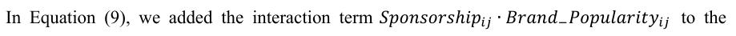

NOTE: contains mathematical notation; text above is the PDF text layer and symbols may be mis-extracted. Image shows the original.

model in Equation (2). 𝐵𝑟𝑎𝑛𝑑4𝑃𝑜𝑝𝑢𝑙𝑎𝑟𝑖𝑡𝑦!" is a three-class categorical variable that describes the

popularity level of the brand in video *j* posted by influencer *i*: whether the brand is a popular brand

(𝑀𝑜𝑟𝑒_𝑃𝑜𝑝𝑢𝑙𝑎𝑟!"), a less popular brand (𝐿𝑒𝑠𝑠_𝑃𝑜𝑝𝑢𝑙𝑎𝑟!" ), or is a relatively new or niche brand

**equation / math rendering (image)**

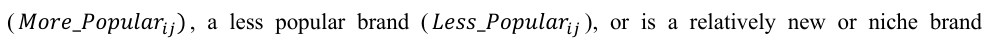

NOTE: contains mathematical notation; text above is the PDF text layer and symbols may be mis-extracted. Image shows the original.

(𝑁𝑜𝑛_𝑆𝑒𝑝ℎ𝑜𝑟𝑎!"). We set 𝑀𝑜𝑟𝑒_𝑃𝑜𝑝𝑢𝑙𝑎𝑟!" as the reference group, so the coefficients of the interaction

terms, 𝜌, capture the extent to which the *reputation-burning effect* differs when the brand is less-well-

known or a non-Sephora brand.

As shown in Table 7, the coefficient of the interaction term 𝑆𝑝𝑜𝑛𝑠𝑜𝑟𝑠ℎ𝑖𝑝!" ∙𝑁𝑜𝑛_𝑆𝑒𝑝ℎ𝑜𝑟𝑎!" is

**equation / math rendering (image)**

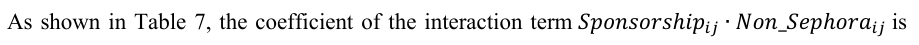

NOTE: contains mathematical notation; text above is the PDF text layer and symbols may be mis-extracted. Image shows the original.

positive and significant, and 𝑆𝑝𝑜𝑛𝑠𝑜𝑟𝑠ℎ𝑖𝑝!" ∙𝐿𝑒𝑠𝑠_𝑃𝑜𝑝𝑢𝑙𝑎𝑟!" is not significant at the 95% confidence

interval but directionally positive. In other words, the *reputation-burning* effect is weaker if the sponsored

video is for a less-well-known brand or for a niche/new brand than if it is for a better-known brand, contrary

to the prediction of the value transfer model in celebrity endorsement research (McCracken 1989). This

divergence may be attributable to the unique brand seeding process of influencer marketing, which often

heavily influences subscribers’ brand discovery (Carmicheal 2021). Casaló, Flavian, and Ibáñez-Sánchez

(2018) found that audiences appreciate sponsored content for small and niche brands because they might

otherwise not have easy access to the information, whereas information about popular brands is easy to find.

It appears that influencers, more than celebrities, are expected to embody the informative role of advertising

(Ozga 1960), and the audience derives more utility from viewing sponsored content when it contains

22 We manually checked the sponsored brand list. A few large brands such as MAC, Ulta Beauty, and L’Oréal Paris are not listed on Sephora’s website, so we assigned them the average value of all products on Sephora’s website. The results are robust when excluding these brands.

𝑃𝑜𝑠𝑡_𝑅𝑒𝑝𝑢𝑡𝑎𝑡𝑖𝑜𝑛!" = 𝐶𝑜𝑛𝑠𝑡𝑎𝑛𝑡 *+* 𝛽∙𝑆𝑝𝑜𝑛𝑠𝑜𝑟𝑠ℎ𝑖𝑝!" + 𝛼∙𝐵𝑟𝑎𝑛𝑑4𝑃𝑜𝑝𝑢𝑙𝑎𝑟𝑖𝑡𝑦!" + 𝜌∙

**equation / math rendering (image)**

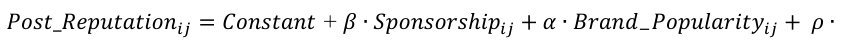

NOTE: contains mathematical notation; text above is the PDF text layer and symbols may be mis-extracted. Image shows the original.

𝑆𝑝𝑜𝑛𝑠𝑜𝑟𝑠ℎ𝑖𝑝!" ∙𝐵𝑟𝑎𝑛𝑑4𝑃𝑜𝑝𝑢𝑙𝑎𝑟𝑖𝑡𝑦!" + 𝛾 𝐶𝑜𝑛𝑡𝑟𝑜𝑙𝑠!" + 𝑀𝑜𝑛𝑡ℎ!" + 𝜀!"

**equation / math rendering (image)**

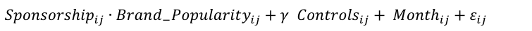

NOTE: contains mathematical notation; text above is the PDF text layer and symbols may be mis-extracted. Image shows the original.

(9)

Electronic copy available at: https://ssrn.com/abstract=4071188

Page 40

40

information about less-well-known brands (Rochet and Tirole 2006). See Web Appendix Section C.4 for

supportive anecdotal evidence that audiences appreciate influencers who enable brand discovery, even in

sponsored videos.

**Table 7. Heterogeneity by Brand Popularity**

| VARIABLES | ESTIMATES | SE . . |
| --- | --- | --- |
| Sponsorship(Reference: More Popular) _ | 000309*** - . | (0000529) . |
| Less Popular _ | 0000715 - . | (0000519) . |
| Non Sephora _ | 0000289 - . | (0000404) . |
| SponsorshipXLess Popular _ SponsorshipXNon Sephora _ | 0000959 . 000127** . | (0000637) . (0000479) . |
|  | InfluencerCharacteristics |  |
| Log Channel _ _ Preceding Subscribers _ | 0996*** . | (0000511) . |
| Log Days Since First Posting _ _ _ _ | 000426*** - . | (0000429) . |
| Log Channel Title Length _ _ _ | 000133* . | (0000542) . |
| Log Weekly Video Number Log_ Days fr_ om Las_ t Posting _ _ _ _ Female Log Age _ Constant | 0000345 - . 000165*** - . 0000252 . 000125** . 00780*** . | (0000355) . (0000222) . (0000415) . (0000419) . (000696) . |
| Observations AIC BIC | 63880 8555678 - . 8543531 - . |  |

NOTE: table converted from PDF layout to HTML text; cell boundaries are reconstructed. See PDF if exact alignment matters.

*5. CONCLUSION AND DISCUSSION*

We analyzed how an influencer’s reputation is affected by posting a sponsored video relative to posting an

equivalent organic video. We employed state-of-the-art video analytics on user-generated videos and used

DFL reweighting to create matched treatment and control groups of influencer-video pairs. An empirical

analysis of the matched sample revealed a *reputation-burning effect*; that is, posting a sponsored video,

Electronic copy available at: https://ssrn.com/abstract=4071188

Page 41

41

relative to posting a similar organic video, led to a loss of 0.19% of the influencer’s reputation. The results

were robust to hypothetical *unobservables* and extensive robustness tests.

We found that the *reputation-burning effect* was stronger among influencers with larger audiences.

An analysis of audience responses, as reflected in the numbers of likes and comments, and trust in the

comment text revealed a larger discrepancy in audience responses to sponsored and organic videos for

influencers with larger (vs. smaller) audiences. We also explored heterogeneous effects by influencer-video

fit and brand popularity. We found that a high *fit* between the sponsored content and the influencer’s “usual”

content mitigates the reputation-burning effect, perhaps because the high fit makes the influencer appear

like a more credible source of product information (Sternthal, Dholakia, and Leavitt 1978). Furthermore,

the *reputation-burning* effect is mitigated when the brand is less well-known, perhaps because the

influencer can provide brand information to which the audience would otherwise not have easy access

(Casaló, Flavian, and Ibáñez-Sánchez 2018).

Our study empirically validates the fundamental assumption of several theoretical works on social

influencers that brand sponsorship harms influencer reputation (Fainmesser and Galeotti 2021; Mitchell

2021). We also contribute to the emerging research on influencer video advertising, the newest form of

influencer marketing. Finally, we offer valuable comparisons with the celebrity endorsement literature

(Choi and Rifon 2012; Sternthal, Dholakia, and Leavitt 1978). While celebrity endorsements might benefit

more from collaborating with better-known brands, we found that the reputation-burning effect is mitigated

when the sponsored post features less-well-known brands, highlighting the unique, informative role that

audiences expect from social influencers.

This study has managerial implications for influencers, brands, and social media platforms. *For*

*influencers*, our estimation of the effect of posting a sponsored video offers a baseline with which

influencers can evaluate the hidden economic trade-off involved in sponsorship offers. Our findings also

suggest that influencers could be strategic in the timing of posting and the content of sponsored videos. It

is advisable that influencers post sponsored content aligned with their usual style (i.e., high fit) and whose

Electronic copy available at: https://ssrn.com/abstract=4071188

Page 42

42

sponsoring brands are less-well-known. Moreover, crafting high-quality sponsored videos such as videos

with higher brightness, saturation, and motion magnitude level can effectively alleviate the reputation-

burning effect (see Web Appendix Section C.1). For *brands*, our results may inform influencer selection.

Most brands currently use influencer reputation as a primary criterion for choosing influencers (Hwang,

Liu, and Srinivasan 2021). However, our results suggest that influencers with more subscribers may not

necessarily be the best brand partners. In fact, when promoting a brand, influencers with larger audiences

tend to elicit more negative audience reactions, including fewer comments, lower engagement, and reduced

trust, than influencers with smaller audiences. Such negative audience reactions may also extend to the

promoted brand. In addition, our results suggest that brands should recruit influencers whose usual content

is closely related to the products to be promoted (i.e., high fit). *For platforms*, we caution that the increasing

prevalence of influencer–brand collaboration may threaten long-term audience engagement. For example,

Facebook announced the demise of Lasso, its short video-sharing platform (similar to TikTok), due to a

lack of active users.<sup>23</sup> Platforms should be advised that brand sponsorship will hurt influencer reputation

and receptivity among audiences, potentially “turning audience away.” Platforms eager to mitigate this

issue could consider charging influencers for posting sponsored videos, similar to advertisement

monetization. Doing so could help offset the platform-wide audience engagement drop and discourage

excessive sponsored content. Platforms could also caution influencers about the risks of sponsorship and

motivate them to post organic content, thereby reducing the exodus of active users who have lost trust in

influencers and become less engaged on the platform.

This paper is not without limitations. First, to ensure a sufficient sample size of organic and

sponsored postings, we included only top and active influencers. Readers should keep this caveat in mind

when considering the implications for nano-influencers. Second, we did not have access to YouTube’s

recommendation algorithm to fully examine whether it affects video views and, consequently, affects

subsequent (un)subscriptions of influencers. In Web Appendix Section B.3, we found no significant

23 https://techcrunch.com/2020/07/01/lasso-facebook-tiktok-shut-down/.

Electronic copy available at: https://ssrn.com/abstract=4071188

Page 43

43

difference in the video views to similar sponsored and organic videos, which suggests that the

recommendation does not discriminate based on sponsorship status. We hope that future studies can gain

access to the algorithm and explore this possibility more rigorously. In addition, we do not consider

competition among influencers; for example, the growth of one influencer’s reputation might affect

another’s ability to attract and retain followers. However, such a competition effect may be less profound

in our context than in other contexts such as consumer purchase because audiences can follow many

influencers simultaneously and do not have to unfollow one influencer to follow another. Lastly, we do not

know the proportion of viewers who noticed each video’s sponsorship disclosure. For example, if the

disclosure appeared at the end of the description box, some viewers might not have seen it. Thus, our

analyses report a conservative estimate of the reputation-burning effect, assuming that every audience is

ensured to be aware of a sponsorship disclosure.

Our research motivates several directions for future research. First, to some extent, the *reputation-*

*burning effect* implies a trade-off for influencers between sustaining their reputation by creating organic

content and capitalizing on their existing reputations for profit through brand-sponsored content, even if it

may come at the expense of their future reputations and potential profit opportunities. Thus, it is worth

investigating influencers’ optimal video-posting policy that maximizes their long-term payoff. Second,

though our findings are arguably transferable to other contexts, future research should investigate the

*reputation-burning effect* among influencers in other categories and on other platforms. Lastly, sponsored

content can take place in various forms in terms of when and how a product is featured in the video. In this

study, we do not differentiate these different forms, and we encourage future research to investigate further

in this direction.

#### *REFERENCES*

Abendroth LJ, Heyman JE (2013) Honesty is the best policy: The effects of disclosure in word-of-mouth

marketing. *J. Mark. Commun.* 19(4):245–257. Abosag I, Ramadan ZB, Baker T, Jin Z (2020) Customers’ need for uniqueness theory versus brand

congruence theory: The impact on satisfaction with social network sites. *J. Bus. Res.* 117:862–872.

Electronic copy available at: https://ssrn.com/abstract=4071188

Page 44

44

Amos C, Holmes G, Strutton D (2008) Exploring the relationship between celebrity endorser effects and

advertising effectiveness: A quantitative synthesis of effect size. *Int. J. Advert.* 27(2):209–234. Arsena A, Silvera DH, Pandelaere M (2014) Brand trait transference: When celebrity endorsers acquire

brand personality traits. *J. Bus. Res.* 67(7):1537–1543. Athey S, Imbens GW (2006) Identification and inference in nonlinear difference-in-differences models.

*Econometrica* 74(2):431–497. Audrezet A, de Kerviler G, Moulard JG (2020) Authenticity under threat: When social media influencers

need to go beyond self-presentation. *J. Bus. Res.* 117:557–569. Austin PC (2011) An introduction to propensity score methods for reducing the effects of confounding in

observational studies. *Multivar. Behav. Res.* 46(3):399–424. Austin PC, Stuart EA (2015) Moving towards best practice when using inverse probability of treatment

weighting (IPTW). *Stat. Med.* 34(28):3661–3679. Avery J, Israeli A (2020) Influencer marketing. *Harv. Bus. Sch. Tech. Note* N9-520-075. Azoulay P, JSG, Wang J (2010) Superstar extinction. *Q. J. Econ*. 125(2):54–589. Barker S (2019) Micro vs. macro influencer marketing: Know the difference. Accessed November 10, 2021,

https://shanebarker.com/blog/macro-vs-micro-influencer-marketing-campaign/. Batra R, Homer PM (2004) The situational impact of brand image beliefs. *J. Consum. Psychol.* 14(3):318–

330. Bell A, Chetty R, Jaravel X, Petkova N, Van Reenen J (2019) Who becomes an inventor in America? The

importance of exposure to innovation. *Q. J. Econ.* 134(2):647–713. Bharadwaj N, Ballings M, Naik PA, Moore M, Arat MM (2022) A new livestream retail analytics

framework to assess the sales impact of emotional displays. *J. Mark.* 86(1):27–47. Bharath ST, Dahiya S, Saunders A, Srinivasan A (2011). Lending relationships and loan contract terms.

*Rev. Financ. Stud.* 24(4): 1141–1203. Boerman, S, Willemsen LM, Van Der Aa EP (2017) “This post is sponsored” effects of sponsorship

disclosure on persuasion knowledge and electronic word of mouth in the context of Facebook. *J. Interact. Market.*, 38(1):.82–92. Brooks A (2020) How can creators benefit from branded content ads? *Vamp.* Accessed November 10, 2021,

https://vamp-brands.com/blog/2020/03/23/how-can-creators-benefit-from-branded-content-ads. Carmicheal K (2021) What is content seeding & how does it work? Accessed January 12, 2022,

https://blog.hubspot.com/marketing/content-seeding. Casaló LV, Flavian C, Ibáñez-Sánchez S (2018) Influencers on Instagram: Antecedents and consequences

of opinion leadership. *J. Bus. Res.* 117:510–519. Chen X, Jiang L, Miao S, Shi C (2020) Time to leave your comfort zone? Optimal variation-seeking

strategies for social media influencers on streaming media platforms. *SSRN*, https://ssrn.com/abstract=3655848. Choi, SM, Rifon NJ (2012) It is a match: The impact of congruence between celebrity image and consumer

ideal self on endorsement effectiveness. *Psychol. Mark.* 29(9):639–650. Cohen J (2013) *Statistical Power Analysis for the Behavioral Sciences* (2<sup>nd</sup> Edition, Routledge, Cambridge,

MA). DiNardo J, Fortin NM, Lemieux T (1996) Labor market institutions and the distribution of wages, 1973–

1992: A semiparametric approach. *Econometrica* 64(5):1001–1044. DiPrete TA, Gangl M (2004) Assessing bias in the estimation of causal effects: Rosenbaum bounds on

matching estimators and instrumental variables estimation with imperfect instruments. *Sociol. Methodol.* 34(1):271–310. Ekman P, Oster H (1979) Facial expressions of emotion. *Annu. Rev. Psychol*. 30(1):527–554. Eldor K (2019) Should Instagram also make follower numbers invisible? *Forbes*. Accessed November 10,

2021, https://www.forbes.com/sites/karineldor/2019/07/31/should-instagram-also-make-followernumbers-invisible/?sh=21e24ee463e2.

Electronic copy available at: https://ssrn.com/abstract=4071188

Page 45

45

Ershov D, Mitchell M (2020) The effects of influencer advertising disclosure regulations: Evidence from

Instagram. *Proc. 21st ACM Conf. on Economics and Computation* (Association for Computing Machinery, New York, NY), 73–74. https://doi.org/10.1145/3391403.3399477. Evans NJ, Wojdynski BW, Hoy M (2018) How sponsorship transparency mitigates negative effects of

advertising recognition. *Int. J. Advert.* 38(3):1–19. Experticity (2016) New research shows micro-influencers have more impact than average consumers.

Accessed November 10, 2021, https://go2.experticity.com/rs/288-AZS-731/images/Experticity- KellerFaySurveySummary_.pdf. Eyben F, Wöllmer M, Schuller B (2010) OpenSMILE: The Munich versatile and fast open-source audio

feature extractor. *Proc. 18th ACM International Conf. on Multimedia* (Association for Computing Machinery, New York), 1459–1462. Fainmesser IP, Galeotti A (2021) The market for online influence. *Am. Econ. J. Microecon.* 13(4):332–372. Firpo S (2007) Efficient semiparametric estimation of quantile treatment effects. *Econometrica* 75:259–

276. Forrester J (2018) 47% of consumers are fatigued by repetitive influencers. *Talking Influence* (August 3),

https://talkinginfluence.com/2018/08/03/47-of-consumers-are-fatigued-by-repetitive-influencers/. Fraccaro PJ, Jones BC, Vukovic J, Smith FG, Watkins CD, Feinberg DR, et al. (2011) 47% of consumers

are fatigued by repetitive influencers. *J. Evol. Psychol.* 9(1):57–67. FTC (2019) The FTC’s endorsement guides: Being up-front with consumers. Accessed August 2023,

https://www.ftc.gov/news-events/topics/truth-advertising/advertisement-endorsements. Geyser W (2021) The state of influencer marketing 2021: Benchmark report. *Influencer Marketing Hub*,

Accessed November 10, 2021, https://influencermarketinghub.com/influencer-marketingbenchmark-report-2021. Haenlein M, Anadol E, Farnsworth T, Hugo H, Hunichen J, Welte D (2020) Navigating the new era of

influencer marketing: How to be successful on Instagram, TikTok, & Co. *Calif. Manage. Rev.* 63(1):5–25. He Z-L, Wong P-K (2004) Exploration vs. exploitation: An empirical test of the ambidexterity hypothesis.

*Organ. Sci*. 15(4):481–494. Hirano K, Imbens GW, Ridder G (2003) Efficient estimation of average treatment effects using the

estimated propensity score. *Econometrica* 71:1161–1189. Huang Y, Morozov I (2022) Video advertising by twitch influencers. *SSRN*,

https://ssrn.com/abstract=4065064. Hughes C, Swaminathan V, Brooks G (2019) Driving brand engagement through online social

influencers: An empirical investigation of sponsored blogging campaigns. *J. Mark.* 83(5):78–96. Hung KH, Chan KW, Tse CH (2011) Assessing celebrity endorsement effects in China: A consumer-

celebrity relational approach. *J. Advert. Res.* 51(4):608. Hwang S, Liu X, Srinivasan K (2021) Voice analytics of online influencers—Soft selling in branded

videos. *SSRN*, https://ssrn.com/abstract=3773825. Jäger S (2016) How substitutable are workers? Evidence from worker deaths. *SSRN*,

https://ssrn.com/abstract=2925897. Keyhole (2020) How do I calculate engagement rate? Accessed August 30, 2021,

https://keyhole.co/blog/how-do-i-calculate-engagement-rate/. Kirmani A, Shiv B (1998) Effects of source congruity on brand attitudes and beliefs: The moderating role

of issue-relevant elaboration. *J. Consum. Psychol.* 7(1):25–47. Knoll J, Matthes J (2017) The effectiveness of celebrity endorsements: A meta-analysis. *J. Acad. Market.*

*Sci.* 45(1):55–75. LaLumia S (2013) The EITC, tax refunds, and unemployment spells. *Am. Econ. J. Econ. Policy* 5(2):188–

221. Lee JA, Eastin MS (2020) I like what she's #endorsing: The impact of female social media influencers'

perceived sincerity, consumer envy, and product type. *J. Interact. Advert.* 20(1):76–91.

Electronic copy available at: https://ssrn.com/abstract=4071188

Page 46

46

Leung FF, Gu FF, Li Y, Zhang JZ, Palmatier RW (2022) Influencer marketing effectiveness. *J. Mark*.

86(6):93–115. Liu Q (2011) Information acquisition and reputation dynamics. *Rev. Econ. Stud.* 78(4):1400–1425. Liu Q, Skrzypacz A (2014) Limited records and reputation bubbles. *J. Econ. Theory* 151:2–29. Manchanda P, Packard G, Pattabhiramaiah A (2015) Social dollars: The economic impact of customer

participation in a firm-sponsored online customer community. *Mark. Sci.* 34(3):367–387. March JG (1991) Exploration and exploitation in organizational learning. *Organ. Sci.* 2(1):71–87. McCaffrey DF, Griffin BA, Almirall D, Slaughter ME, Ramchand R, Burgette LF (2013) A tutorial on

propensity score estimation for multiple treatments using generalized boosted models. *Stat. Med.* 32(19):3388–3414. McCracken G (1989) Who is the celebrity endorser? Cultural foundations of the endorsement process. *J.*

*Consum. Res.* 16(3):310–321. McQuarrie EJ, Miller J, Phillips BJ (2013) The megaphone effect: Taste and audience in fashion

blogging. *J. Consum. Res.* 40:136–158. Mediakix (2020a) How do influencers make money with YouTube sponsorships? Accessed August 30,

2021, https://mediakix.com/influencer-marketing-resources/how-do-influencers-make-moneywith-youtube-sponsorships. Mediakix (2020b) Sponsored influencer content: What you need to know. Accessed August 30, 2021,

https://mediakix.com/influencer-marketing-resources/sponsored-influencer-content-what-youneed-to-know. Miller FM, Allen C (2012) How does celebrity meaning transfer? Investigating the process of meaning

transfer with celebrity affiliates and mature brands. *J. Consum. Psychol.* 22(3):443–452. Mitchell M (2021) Free ad(vice): Internet influencers and disclosure regulation. *RAND J. Econ*. 52(1):3–

21. Mohammad SM, Turney PD (2013) Crowdsourcing a word-emotion association lexicon. *Comput. Intell.*

29(3):436–465. Moorthy AK, Obrador P, Oliver N (2010) Towards computational models of the visual aesthetic appeal of

consumer videos. *Proc. 11th European Conf. on Computer Vision* (Springer-Verlag, Berlin), 1–14. Morton F (2020) Influencer marketing: An exploratory study on the motivations of young adults to follow

social media influencers. *J. Digit. Soc. Media Mark.* 8(2):156–165. Ozga SA (1960) Imperfect markets through lack of knowledge. *Q. J. Econ.* 74:29–52. Pei A, Mayzlin D (2021) Influencing social media influencers through affiliation. *Mark. Sci.* 41(3):593–

615. Peterson, RA, Cannito MP, Brown SP (1995) An exploratory investigation of voice characteristics and

selling effectiveness. *J. Pers. Sell. Sales Manag.* 15(1):1–15. Quoc Le, Mikolov T (2014) Distributed representations of sentences and documents. *Proc. Mach. Learn.*

*Res*. 32(2):1188–1196. Rajaram P, Manchanda P (2020) Video influencers: Unboxing the mystique. *SSRN*,

https://ssrn.com/abstract=3752107. Rochet, J-C, Tirole J (2006) Two-sided markets: A progress report. *RAND J. Econ.* 37(3):645–667. Rosenbaum, PR (2002) *Observational Studies*, 2nd ed. (Springer, New York). Rosenbaum PR, Rubin DB (1985) Constructing a control group using multivariate matched sampling

methods that incorporate the propensity score. *Am. Stat.* 39(1):33–38. Rubin DB (2001) Using propensity scores to help design observational studies: Application to the tobacco

litigation. *Health Serv. Outcomes Res. Methodol.* 2:169–188. Scherer KR, London H, Wolf JJ (1973) The voice of confidence: Paralinguistic cues and audience

evaluation. *J. Res. Pers.* 7(1):31–44. Schwemmer C, Ziewiecki S (2018) Social media sellout: The increasing role of product promotion on

YouTube. *Soc. Media Soc.* 4(3):1-20.

Electronic copy available at: https://ssrn.com/abstract=4071188

Page 47

47

Segura, P (2018) Your new target audience: Segments of micro-influencers. Audiense.com. Accessed

November 10, 2021, https://resources.audiense.com/en/blog/your-new-target-audience-segmentsof-micro-influencers. Sokolova, K, Kefi H (2020) Instagram and YouTube bloggers promote it, why should I buy? How

credibility and parasocial interaction influence purchase intentions. *J. Retail Consum Serv.* 53(1):101742. Sonnenberg A (2021) How to partner with YouTube micro-influencers. *Soc. Med. Exam.* (September 18). Sternthal B, Dholakia R, Leavitt C (1978) The persuasive effect of source credibility: Tests of cognitive

response. *J. Consum. Res.* 4(4):252–260. Sun M, Zhu F (2013) Ad revenue and content commercialization: Evidence from blogs. *Manag. Sci.*

59(10):2314–2331. Tabor E (2020) Credibility and trust are key to authentic influencer marketing. Accessed December,

2021, https://www.forbes.com/sites/forbesagencycouncil/2020/04/08/credibility-and-trust-arekey-to-authentic-influencer-marketing. Tripp C, Jensen TD, Carlson L (1994) The effects of multiple product endorsements by celebrities on

consumers’ attitudes and intentions. *J. Consum. Res.* 20(4):535–547. Valsesia F, Proserpio D, Nunes JC (2020) The positive effect of not following others on social media. *J.*

*Mark. Res.* 57(6):1152–1168. Van Driel L, Dumitrica D (2021) Selling brands while staying “authentic”: The professionalization of

Instagram influencers. *Convergence* 27(1):66–84. Weber N (2018) How to make millions with macro influencers. *Neal Shaeffer*, accessed December, 2021,

https://nealschaffer.com/macro-influencers/. Wies S, Bleier A, Edeling A (2022) Finding Goldilocks influencers: How follower count drives social

media engagement. *J. Mark.* 87(3):383–405. Yagan D (2015) Capital tax reform and the real economy: The effects of the 2003 dividend tax cut. *Am.*

*Econ. Rev.* 105(12):3531–3563. Yang J, Zhang J, Zhang Y (2021) First law of motion: Influencer video advertising on TikTok. *SSRN*,

https://ssrn.com/abstract=3815124. Yeh H-H, Yang C-Y, Lee M-S, Chen C-S (2013) Video aesthetic quality assessment by temporal

integration of photo-and motion-based feature. *IEEE Trans. Multimedia* 15(8):1944–1957. Zhang S, Lee D, Singh PV, Srinivasan K (2022) What makes a good image? Airbnb demand analytics

leveraging interpretable image features. *Manage. Sci.* 68(8):5557–6354. Zhang S, Mehta N, Singh PV, Srinivasan K (2021) Frontiers: Can an artificial intelligence algorithm

mitigate racial economic inequality? An analysis in the context of Airbnb. *Mark. Sci.* 40(5):813– 820. Zhou M, Chen GH, Ferreira P, Smith MD (2021) Consumer behavior in the online classroom: Using video

analytics and machine learning to understand the consumption of video courseware. *J. Mark. Res.* 58(6):1079–1100.

Electronic copy available at: https://ssrn.com/abstract=4071188